**CS4132 Data Analytics**

# "Effects of Covid-19 on Amusement Parks" by Drew Michael Terren Ramirez

Important Note: Please keep your report concise and relevant (i.e. show only relevant steps and visualizations used to answer your research questions).

# Table of Content (with relevant hyperlinks to sections)

## Motivation & Background

## Summary of Research Questions & Results

## Dataset

## Methodology

## Data Cleaning

### Dataset 1 (AECOM Theme Index)

### Dataset 2 (Queue-times)

## EDA

### Dataset 1 (AECOM Theme Index)

### Dataset 2 (Queue-times)

## Results Findings & Conclusions

### Question 1 (Trend and Drop)

### Question 2 (Timing of Closure)

## Recommendations or Further Works

## References

# Motivation and Background

Give an overview of the project, motivation, background and goals.

The project is about analysing the popularity of amusement parks, mainly how it was affected by the pandemic. There have definitely been impacts to the amusement parks, but by how much? That is the question I wish to analyse. The motivation behind this project was visiting an amusement for the first time since the pandemic struck, and realising that there were already many people there, so I wanted to know how and when people started coming back. The goal is to have a better understanding of how badly the pandemic affecting the amusement parks and how they have recovered.

# Summary of Research Questions & Results

Repeat your research questions in a numbered list. After each research question, clearly state the answer/conclusion you determined. Do not give details or justifications yet — just the answer

1. Based on the attendance data, was there an increasing trend in the attendance prior to the pandemic? And when the pandemic struck, how drastic was the decrease in attendance?

   > Answer: 2020 had the worst effects from the pandemic, and in 2021, parks have already restored the number of days open back to the norm. The effect of the pandemic was the worst from April to May 2020, and from July, most parks have already reopened.

# Dataset

Numbered list of dataset (with downloadable links) and a brief but clear description of each dataset used. Draw reference to the numbering when describing methodology (data cleaning and analysis).

1. https://aecom.com: There are theme indexes listing the top 25 amusement parks from 2012 onwards, including the percentage change in attendance.
2. https://queue-times.com: The data on this site shows the relative crowd level for each park for each day.

# Methodology

You should demonstrate the data science life cycle here (from data acquisition to cleaning to EDA and analysis etc).

### Data Acquisition:

Scraping from https://aecom.com: There are theme indexes listing the *top 25* amusement parks from 2012 onwards. I will be scraping all the data using tabula.py. This is a python library that is able to read pdfs and convert them into pandas dataframes.

Scraping from https://queue-times.com: The data on this site shows the relative crowd level for each park for each day. This is in terms of a percentage. When there is no data available, the park is closed on that day. Data for 2016 to 2021 was scraped for each day for each park which has a "Calendar" page on the site. This was done via python requests.

### Data Cleaning:

Data from https://aecom.com in general had very different formatting across different years. Tabula.py would also read multilined names from the pdf as separate rows in the data frames, so these extra unnecessary lines would need to be cleaned off. Afterwards, the `Change` and `Current` data are extracted into 2 DataFrames called `merged_change` and `merged` respectively, to be used in the EDA section.

Raw data from https://queue-times.com did not require cleaning past the data acquisition. However, I filtered out the useful data by considering which parks were open since a certain point, so that there would be less NA's.

### EDA:

For the first dataset, I created multiple visualisations using different types of graphs. In general, they are able to show that there is an increasing trend from 2012 through 2019, and show the sharp decrease in 2020. Some visualisations are able to show trends of the highest and lowest in the top 25, while others show the spread of the data.

For the second dataset, from the data cleaning, parks are filtered from if they are open in 2016 and if they are open in 2019, giving 2 different sets of parks, with corresponding data in `open16` and `open19`. The data from these is then placed into a heatmap, and similarly `month2020` which shows the percentage of days open in 2020 by month is put into a heatmap too.

### Results Findings and Conclusion

For question 1, trends were observed from the *joyplot* of the percentage change, and the *boxenplot* of the attendance over the years.

For question 2, the *heatmaps* with varying data input are analysed.

## Data Acquisition

Display the data which will be used in the project. The data should be saved in .xlsx or .csv format to be submitted with the project. If webscraping has been done to obtain your data, save your webscraping code in another jupyter notebook as appendix to be submitted separately from the report. Import and display each dataset in a dataframe. For each dataset, give a brief overview of the data it contains, and explain the meaning of columns that are relevant to the project.

```python
import pandas as pd
import numpy as np
import seaborn as sns
import matplotlib.pyplot as plt
%matplotlib inline
import joypy
```

### Dataset 1 (AECOM Theme Index)

`df2012`, and similarly `df{year}` is the table from the AECOM Theme Index pdf on top 25 amusement parks worldwide for the respective year.

The columns are summarised as follows:  
`Change` is the change from previous to current.  
`Current` is the attendance in that year.  
`Previous` is the attendance in the previous year.

```python
df2012=pd.read_csv('df2012.csv',index_col=0,usecols=[1,2,3,4])
df2012
```

| Name | Change | Current | Previous |
| --- | --- | --- | --- |
| MAGIC KINGDOM | NaN | NaN | NaN |
| NaN | 2.3% | 17,536,000 | 17,142,000 |
| at Walt Disney World, Lake Buena Vista, Florida | NaN | NaN | NaN |
| DISNEYLAND | NaN | NaN | NaN |
| NaN | -1.1% | 15,963,000 | 16,140,000 |
| ... | ... | ... | ... |
| NaN | 1.8% | 4,200,000 | 4,125,000 |
| Kaatsheuvel, Netherlands | NaN | NaN | NaN |
| OCT EAST | NaN | NaN | NaN |
| NaN | 7.9% | 4,196,000 | 3,890,000 |
| Shenzhen, China | NaN | NaN | NaN |

75 rows × 3 columns

```python
df2013=pd.read_csv('df2013.csv',index_col=0,usecols=[1,2,3,4])
df2013
```

| Name | Change | Current | Previous |
| --- | --- | --- | --- |
| MAGIC KINGDOM at Walt Disney World, Lake Buena Vista, FL | 6.0% | 18,588,000 | 17,536,000 |
| TOKYO DISNEYLAND, Tokyo, Japan | 15.9% | 17,214,000 | 14,847,000 |
| DISNEYLAND, Anaheim, CA | 1.5% | 16,202,000 | 15,963,000 |
| TOKYO DISNEY SEA, Tokyo, Japan | 11.3% | 14,084,000 | 12,656,000 |
| EPCOT at Walt Disney World, Lake Buena Vista, FL | 1.5% | 11,229,000 | 11,063,000 |
| DISNEYLAND PARK AT DISNEYLAND PARIS, | -6.9% | 10,430,000 | 11,200,000 |
| Marne-La-Vallee, France | NaN | NaN | NaN |
| DISNEY'S ANIMAL KINGDOM at Walt Disney World, | 2.0% | 10,198,000 | 9,998,000 |
| Lake Buena Vista, FL | NaN | NaN | NaN |
| DISNEY'S HOLLYWOOD STUDIOS at Walt Disney World, | 2.0% | 10,110,000 | 9,912,000 |
| Lake Buena Vista, FL | NaN | NaN | NaN |
| UNIVERSAL STUDIOS JAPAN, Osaka, Japan | 4.1% | 10,100,000 | 9,700,000 |
| DISNEY'S CALIFORNIA ADVENTURE, Anaheim, CA | 9.5% | 8,514,000 | 7,775,000 |
| ISLANDS OF ADVENTURE at Universal Orlando, FL | 2.0% | 8,141,000 | 7,981,000 |
| OCEAN PARK, Hong Kong SAR | 0.5% | 7,475,000 | 7,436,000 |
| HONG KONG DISNEYLAND, Hong Kong SAR | 10.4% | 7,400,000 | 6,700,000 |
| LOTTE WORLD, Seoul, South Korea | 15.9% | 7,400,000 | 6,383,000 |
| EVERLAND, Gyeonggi-Do, South Korea | 6.6% | 7,303,000 | 6,853,000 |
| UNIVERSAL STUDIOS at Universal Orlando, FL | 14.0% | 7,062,000 | 6,195,000 |
| UNIVERSAL STUDIOS HOLLYWOOD, Universal City, CA | 4.0% | 6,148,000 | 5,912,000 |
| NAGASHIMA SPA LAND, Kuwana, Japan | -0.2% | 5,840,000 | 5,850,000 |
| SEAWORLD, Orlando, FL | -5.0% | 5,090,000 | 5,358,000 |
| EUROPA PARK, Rust, Germany | 6.5% | 4,900,000 | 4,600,000 |
| WALT DISNEY STUDIOS PARK AT DISNEYLAND PARIS, Marne- | -6.9% | 4,470,000 | 4,800,000 |
| La-Vallee, France | NaN | NaN | NaN |
| SEAWORLD, San Diego, CA | -3.0% | 4,311,000 | 4,444,000 |
| TIVOLI GARDENS, Copenhagen, Denmark | 4.1% | 4,200,000 | 4,033,000 |
| DE EFTELING, Kaatsheuvel, Netherlands | -1.2% | 4,150,000 | 4,200,000 |
| YOKOHAMA HAKKEIJIMA SEA PARADISE, Yokohama, Japan | 2.4% | 4,149,000 | 4,050,000 |

```python
df2014=pd.read_csv('df2014.csv',index_col=0,usecols=[1,2,3,4])
df2014
```

| Name | Change | Current | Previous |
| --- | --- | --- | --- |
| MAGIC KINGDOM at Walt Disney World, | 4.0% | 19,332,000 | 18,588,000 |
| Lake Buena Vista, FL | NaN | NaN | NaN |
| TOKYO DISNEYLAND, Tokyo, Japan | 0.5% | 17,300,000 | 17,214,000 |
| DISNEYLAND, Anaheim, CA | 3.5% | 16,769,000 | 16,202,000 |
| TOKYO DISNEY SEA, Tokyo, Japan | 0.1% | 14,100,000 | 14,084,000 |
| UNIVERSAL STUDIOS JAPAN, Osaka, Japan | 16.8% | 11,800,000 | 10,100,000 |
| EPCOT at Walt Disney World, Lake Buena Vista, FL | 2.0% | 11,454,000 | 11,229,000 |
| DISNEY'S ANIMAL KINGDOM at Walt Disney World, | 2.0% | 10,402,000 | 10,198,000 |
| Lake Buena Vista, FL | NaN | NaN | NaN |
| DISNEY'S HOLLYWOOD STUDIOS | 2.0% | 10,312,000 | 10,110,000 |
| at Walt Disney World, Lake Buena Vista, FL | NaN | NaN | NaN |
| DISNEYLAND PARK AT DISNEYLAND PARIS, | -4.7% | 9,940,000 | 10,430,000 |
| Marne-La-Vallee, France | NaN | NaN | NaN |
| DISNEY'S CA ADVENTURE, Anaheim, CA | 3.0% | 8,769,000 | 8,514,000 |
| UNIVERSAL STUDIOS at Universal Orlando, FL | 17.0% | 8,263,000 | 7,062,000 |
| ISLANDS OF ADVENTURE at Universal Orlando, FL | 0.0% | 8,141,000 | 8,141,000 |
| OCEAN PARK, Hong Kong SAR | 4.2% | 7,792,000 | 7,475,000 |
| LOTTE WORLD, Seoul, South Korea | 2.8% | 7,606,000 | 7,400,000 |
| HONG KONG DISNEYLAND, Hong Kong SAR | 1.4% | 7,500,000 | 7,400,000 |
| EVERLAND, Gyeonggi-Do, South Korea | 1.1% | 7,381,000 | 7,303,000 |
| UNIVERSAL STUDIOS HOLLYWOOD, Universal City, CA | 11.0% | 6,824,000 | 6,148,000 |
| SONGCHENG PARK, Hangzhou, China | 38.3% | 5,810,000 | 4,200,000 |
| NAGASHIMA SPA LAND, Kuwana, Japan | -3.6% | 5,630,000 | 5,840,000 |
| CHIMELONG OCEAN KINGDOM, Hengqin, China (new) | NaN | 5,504,000 | NaN |
| EUROPA PARK, Rust, Germany | 2.0% | 5,000,000 | 4,900,000 |
| SEAWORLD FL, Orlando, FL | -8.0% | 4,683,000 | 5,090,000 |
| TIVOLI GARDENS, Copenhagen, Denmark | 6.6% | 4,478,000 | 4,200,000 |
| DE EFTELING, Kaatsheuvel, Netherlands | 6.0% | 4,400,000 | 4,150,000 |
| WALT DISNEY STUDIOS PARK AT DISNEYLAND PARIS, | -4.7% | 4,260,000 | 4,470,000 |
| Marne-La-Vallee, France | NaN | NaN | NaN |

```python
df2015=pd.read_csv('df2015.csv',index_col=0,usecols=[1,2,3,4])
df2015
```

| Name | Change | Current | Previous |
| --- | --- | --- | --- |
| MAGIC KINGDOM at Walt Disney World, Lake Buena Vista, FL, U.S. | 6.0% | 20,492,000 | 19,332,000 |
| DISNEYLAND, Anaheim, CA, U.S. | 9.0% | 18,278,000 | 16,769,000 |
| TOKYO DISNEYLAND, Tokyo, Japan | -4.0% | 16,600,000 | 17,300,000 |
| UNIVERSAL STUDIOS JAPAN, Osaka, Japan | 17.8% | 13,900,000 | 11,800,000 |
| TOKYO DISNEY SEA, Tokyo, Japan | -3.5% | 13,600,000 | 14,100,000 |
| EPCOT at Walt Disney World, Lake Buena Vista, FL, U.S. | 3.0% | 11,798,000 | 11,454,000 |
| DISNEY'S ANIMAL KINGDOM | 5.0% | 10,922,000 | 10,402,000 |
| at Walt Disney World, Lake Buena Vista, FL, U.S. | NaN | NaN | NaN |
| DISNEY'S HOLLYWOOD STUDIOS | 5.0% | 10,828,000 | 10,312,000 |
| at Walt Disney World, Lake Buena Vista, FL, U.S. | NaN | NaN | NaN |
| DISNEYLAND PARK AT DISNEYLAND PARIS, | 4.2% | 10,360,000 | 9,940,000 |
| Marne-la-Vallée, France | NaN | NaN | NaN |
| UNIVERSAL STUDIOS at Universal Orlando, FL, U.S. | 16.0% | 9,585,000 | 8,263,000 |
| DISNEY'S CA ADVENTURE, Anaheim, CA, U.S. | 7.0% | 9,383,000 | 8,769,000 |
| ISLANDS OF ADVENTURE at Universal Orlando, FL, U.S. | 8.0% | 8,792,000 | 8,141,000 |
| CHIMELONG OCEAN KINGDOM, Hengqin, China | 36.0% | 7,486,000 | 5,504,000 |
| EVERLAND, Gyeonggi-Do, South Korea | 0.6% | 7,423,000 | 7,381,000 |
| OCEAN PARK, Hong Kong SAR | -5.2% | 7,387,000 | 7,792,000 |
| LOTTE WORLD, Seoul, South Korea | -3.9% | 7,310,000 | 7,606,000 |
| HANGZHOU SONGCHENG PARK, Hangzhou, China | 25.5% | 7,289,000 | 5,810,000 |
| UNIVERSAL STUDIOS HOLLYWOOD, Universal City, CA, U.S. | 4.0% | 7,097,000 | 6,824,000 |
| HONG KONG DISNEYLAND, Hong Kong SAR | -9.3% | 6,800,000 | 7,500,000 |
| NAGASHIMA SPA LAND, Kuwana, Japan | 4.3% | 5,870,000 | 5,630,000 |
| EUROPA-PARK, Rust, Germany | 10.0% | 5,500,000 | 5,000,000 |
| SEAWORLD FL, Orlando, FL, U.S. | 2.0% | 4,777,000 | 4,683,000 |
| TIVOLI GARDENS, Copenhagen, Denmark | 5.7% | 4,733,000 | 4,478,000 |
| DE EFTELING, Kaatsheuvel, The Netherlands | 6.4% | 4,680,000 | 4,400,000 |
| SONGCHENG LIJIANG ROMANCE PARK, Lijiang, China | 170.4% | 4,678,000 | 1,730,000 |

```python
df2016=pd.read_csv('df2016.csv',index_col=0,usecols=[1,2,3,4])
df2016
```

| Name | Change | Current | Previous |
| --- | --- | --- | --- |
| MAGIC KINGDOM AT WALT DISNEY WORLD, LAKE BUENA VISTA, FL, U.S. | -0.5% | 20,395,000 | 20,492,000 |
| DISNEYLAND, ANAHEIM, CA, U.S. | -1.8% | 17,943,000 | 18,278,000 |
| TOKYO DISNEYLAND, TOKYO, JAPAN | -0.4% | 16,540,000 | 16,600,000 |
| UNIVERSAL STUDIOS JAPAN, OSAKA, JAPAN | 4.3% | 14,500,000 | 13,900,000 |
| TOKYO DISNEY SEA, TOKYO, JAPAN | -1.0% | 13,460,000 | 13,600,000 |
| EPCOT AT WALT DISNEY WORLD, LAKE BUENA VISTA, FL, U.S. | -0.7% | 11,712,000 | 11,798,000 |
| DISNEY'S ANIMAL KINGDOM AT WALT DISNEY WORLD, LAKE BUENA VISTA, FL, U.S. | -0.7% | 10,844,000 | 10,922,000 |
| DISNEY'S HOLLYWOOD STUDIOS AT WALT DISNEY WORLD, LAKE BUENA VISTA, FL, U.S. | -0.5% | 10,776,000 | 10,828,000 |
| UNIVERSAL STUDIOS AT UNIVERSAL ORLANDO, FL, U.S. | 4.3% | 9,998,000 | 9,585,000 |
| ISLANDS OF ADVENTURE AT UNIVERSAL ORLANDO, FL, U.S. | 6.5% | 9,362,000 | 8,792,000 |
| DISNEY'S CALIFORNIA ADVENTURE, ANAHEIM, CA, U.S. | -0.9% | 9,295,000 | 9,383,000 |
| CHIMELONG OCEAN KINGDOM, HENGQIN, CHINA | 13.2% | 8,474,000 | 7,486,000 |
| DISNEYLAND PARK AT DISNEYLAND PARIS, MARNE LA VALLÉE, FRANCE | -14.2% | 8,400,000 | 9,790,000* |
| LOTTE WORLD, SEOUL, SOUTH KOREA | 11.5% | 8,150,000 | 7,310,000 |
| UNIVERSAL STUDIOS HOLLYWOOD, UNIVERSAL CITY, CA, U.S. | 13.9% | 8,086,000 | 7,097,000 |
| EVERLAND, GYEONGGI-DO, SOUTH KOREA | -3.0% | 7,200,000 | 7,423,000 |
| HONG KONG DISNEYLAND, HONG KONG SAR | -10.3% | 6,100,000 | 6,800,000 |
| OCEAN PARK, HONG KONG SAR | -18.8% | 5,996,000 | 7,387,000 |
| NAGASHIMA SPA LAND, KUWANA, JAPAN | -0.3% | 5,850,000 | 5,870,000 |
| EUROPA PARK, RUST, GERMANY | 1.8% | 5,600,000 | 5,500,000 |
| SHANGHAI DISNEYLAND, SHANGHAI, CHINA | – | 5,600,000 | NEW ENTRY |
| WALT DISNEY STUDIOS PARK AT DISNEYLAND PARIS, MARNE LA VALLÉE, FRANCE | -1.6% | 4,970,000 | 5,050,000* |
| DE EFTELING, KAATSHEUVEL, THE NETHERLANDS | 1.8% | 4,764,000 | 4,680,000 |
| T%IV COHLAI NGAGREDENS, COPENHAGEN, DENMARK | -2.0% | 4,640,000 | 4,733,000 |
| SEAWORLD FLORIDA, ORLANDO, FL, U.S. | -7.9% | 4,402,000 | 4,777,000 |

```python
df2017=pd.read_csv('df2017.csv',index_col=0,usecols=[1,2,3,4])
df2017
```

| Name | Change | Current | Previous |
| --- | --- | --- | --- |
| MAGIC KINGDOM AT WALT DISNEY WORLD, LAKE BUENA VISTA, FL, U.S. | 0.3% | 20,450,000 | 20,395,000 |
| DISNEYLAND, ANAHEIM, CA, U.S. | 2.0% | 18,300,000 | 17,943,000 |
| TOKYO DISNEYLAND, TOKYO, JAPAN | 0.4% | 16,600,000 | 16,540,000 |
| UNIVERSAL STUDIOS JAPAN, OSAKA, JAPAN | 3.0% | 14,935,000 | 14,500,000 |
| TOKYO DISNEYSEA, TOKYO, JAPAN | 0.3% | 13,500,000 | 13,460,000 |
| DISNEY'S ANIMAL KINGDOM AT WALT DISNEY WORLD, LAKE BUENA VISTA, FL, U.S. | 15.3% | 12,500,000 | 10,844,000 |
| EPCOT AT WALT DISNEY WORLD, LAKE BUENA VISTA, FL | 4.2% | 12,200,000 | 11,712,000 |
| SHANGHAI DISNEYLAND, SHANGHAI, CHINA | 96.4% | 11,000,000 | 5,600,000 |
| DISNEY'S HOLLYWOOD STUDIOS AT WALT DISNEY WORLD, LAKE BUENA VISTA, FL, U.S. | -0.5% | 10,722,000 | 10,776,000 |
| UNIVERSAL STUDIOS AT UNIVERSAL ORLANDO, FL, U.S. | 2.0% | 10,198,000 | 9,998,000 |
| CHIMELONG OCEAN KINGDOM, HENGQIN, CHINA | 15.5% | 9,788,000 | 8,474,000 |
| DISNEYLAND PARK AT DISNEYLAND PARIS, MARNE-LA-VALLEE, FRANCE | 15.0% | 9,660,000 | 8,400,000 |
| DISNEY CALIFORNIA ADVENTURE, ANAHEIM, CA, U.S. | 3.0% | 9,574,000 | 9,295,000 |
| ISLANDS OF ADVENTURE AT UNIVERSAL ORLANDO, FL, U.S. | 2.0% | 9,549,000 | 9,362,000 |
| UNIVERSAL STUDIOS HOLLYWOOD, UNIVERSAL CITY, CA, U.S. | 12.0% | 9,056,000 | 8,086,000 |
| LOTTE WORLD, SEOUL, SOUTH KOREA | -17.6% | 6,714,000 | 8,150,000 |
| EVERLAND, GYEONGGI-DO, SOUTH KOREA | -9.5% | 6,310,000 | 6,970,000* |
| HONG KONG DISNEYLAND, HONG KONG SAR | 1.6% | 6,200,000 | 6,100,000 |
| NAGASHIMA SPA LAND, KUWANA, JAPAN | 1.4% | 5,930,000 | 5,850,000 |
| OCEAN PARK, HONG KONG SAR | -3.3% | 5,800,000 | 5,996,000 |
| EUROPA-PARK, RUST, GERMANY | 1.8% | 5,700,000 | 5,600,000 |
| WALT DISNEY STUDIOS PARK AT DISNEYLAND PARIS, MARNE-LA-VALLEE, FRANCE | 4.6% | 5,200,000 | 4,970,000 |
| HDAEN EGFETELING, KAATSHEUVEL, NETHERLANDS | 8.7% | 5,180,000 | 4,764,000 |
| TIVOLI GARDENS, COPENHAGEN, DENMARK | 0.0% | 4,640,000 | 4,640,000 |
| EUNNDIAVENRCSEAL STUDIOS SINGAPORE, SINGAPORE | 2.9% | 4,220,000 | 4,100,000 |

```python
df2018=pd.read_csv('df2018.csv',index_col=0,usecols=[1,2,3,4])
df2018
```

| Name | Change | Current | Previous |
| --- | --- | --- | --- |
| MAGIC KINGDOM THEME PARK AT WALT DISNEY WORLD RESORT, | 2.0% | 20,859,000 | 20,450,000 |
| LAKE BUENA VISTA, FL, U.S. | NaN | NaN | NaN |
| DISNEYLAND PARK AT DISNEYLAND RESORT, ANAHEIM, CA, U.S. | 2.0% | 18,666,000 | 18,300,000 |
| TOKYO DISNEYLAND AT TOKYO DISNEY RESORT, TOKYO, JAPAN | 7.9% | 17,907,000 | 16,600,000 |
| TOKYO DISNEYSEA AT TOKYO DISNEY RESORT, TOKYO, JAPAN | 8.5% | 14,651,000 | 13,500,000 |
| UNIVERSAL STUDIOS JAPAN, OSAKA, JAPAN | -4.3% | 14,300,000 | 14,935,000 |
| DISNEY’S ANIMAL KINGDOM THEME PARK AT WALT DISNEY WORLD RESORT, | 10.0% | 13,750,000 | 12,500,000 |
| LAKE BUENA VISTA, FL, U.S. | NaN | NaN | NaN |
| EPCOT THEME PARK AT WALT DISNEY WORLD RESORT, LAKE BUENA VISTA, FL, U.S. | 2.0% | 12,444,000 | 12,200,000 |
| SHANGHAI DISNEYLAND, SHANGHAI, CHINA | 7.3% | 11,800,000 | 11,000,000 |
| DISNEY’S HOLLYWOOD STUDIOS AT WALT DISNEY WORLD RESORT, | 5.0% | 11,258,000 | 10,722,000 |
| LAKE BUENA VISTA, FL, U.S. | NaN | NaN | NaN |
| CHIMELONG OCEAN KINGDOM, HENGQIN, CHINA | 10.6% | 10,830,000 | 9,788,000 |
| UNIVERSAL STUDIOS FLORIDA THEME PARK AT UNIVERSAL ORLANDO RESORT, FL, U.S. | 5.0% | 10,708,000 | 10,198,000 |
| DISNEY CALIFORNIA ADVENTURE PARK AT DISNEYLAND RESORT, ANAHEIM, CA, U.S. | 3.0% | 9,861,000 | 9,574,000 |
| DISNEYLAND PARK AT DISNEYLAND PARIS, MARNE-LA-VALLEE, FRANCE | 1.9% | 9,843,000 | 9,660,000 |
| UNIVERSAL’S ISLANDS OF ADVENTURE THEME PARK AT UNIVERSAL | 2.5% | 9,788,000 | 9,549,000 |
| ORLANDO RESORT, FL, U.S. | NaN | NaN | NaN |
| UNIVERSAL STUDIOS HOLLYWOOD, UNIVERSAL CITY, CA, U.S. | 1.0% | 9,147,000 | 9,056,000 |
| HONG KONG DISNEYLAND, HONG KONG SAR | 8.1% | 6,700,000 | 6,200,000 |
| LOTTE WORLD, SEOUL, SOUTH KOREA | -11.2% | 5,960,000 | 6,714,000 |
| NAGASHIMA SPA LAND, KUWANA, JAPAN | -0.2% | 5,920,000 | 5,930,000 |
| EVERLAND, GYEONGGI-DO, SOUTH KOREA | -7.3% | 5,850,000 | 6,310,000 |
| OCEAN PARK, HONG KONG SAR | 0.0% | 5,800,000 | 5,800,000 |
| EUROPA PARK, RUST, GERMANY | 0.4% | 5,720,000 | 5,700,000 |
| HDEA NEGFETELING, KAATSHEUVEL, NETHERLANDS | 4.2% | 5,400,000 | 5,180,000 |
| WALT DISNEY STUDIOS PARK AT DISNEYLAND PARIS, MARNE-LA-VALLEE, FRANCE | 1.9% | 5,298,000 | 5,200,000 |
| TENDANCE | NaN | NaN | NaN |
| 1T8IVOLI GARDENS, COPENHAGEN, DENMARK | 4.5% | 4,850,000 | 4,640,000 |
| CHIMELONG PARADISE, GUANGZHOU, CHINA | 11.9% | 4,680,000 | 4,181,000 |

```python
df2019=pd.read_csv('df2019.csv',index_col=0,usecols=[1,2,3,4])
df2019
```

| Name | Change | Current | Previous |
| --- | --- | --- | --- |
| MAGIC KINGDOM THEME PARK AT WALT DISNEY WORLD RESORT, | 0.5% | 20,963,000 | 20,859,000 |
| LAKE BUENA VISTA, FL, U.S. | NaN | NaN | NaN |
| DISNEYLAND PARK, ANAHEIM, CA, U.S. | 0.0% | 18,666,000 | 18,666,000 |
| TOKYO DISNEYLAND, TOKYO, JAPAN | 0.0% | 17,910,000 | 17,907,000 |
| TOKYO DISNEYSEA, TOKYO, JAPAN | 0.0% | 14,650,000 | 14,651,000 |
| UNIVERSAL STUDIOS JAPAN, OSAKA, JAPAN | 1.4% | 14,500,000 | 14,300,000 |
| DISNEY'S ANIMAL KINGDOM AT WALT DISNEY WORLD, LAKE BUENA VISTA, FL, U.S. | 1.0% | 13,888,000 | 13,750,000 |
| EPCOT AT WALT DISNEY WORLD, LAKE BUENA VISTA, FL, U.S. | 0.0% | 12,444,000 | 12,444,000 |
| CHIMELONG OCEAN KINGDOM, HENGQIN, CHINA | 8.4% | 11,736,000 | 10,830,000 |
| DISNEY'S HOLLYWOOD STUDIOS AT WALT DISNEY WORLD, LAKE BUENA VISTA, FL, U.S. | 2.0% | 11,483,000 | 11,258,000 |
| SHANGHAI DISNEYLAND, SHANGHAI, CHINA | -5.0% | 11,210,000 | 11,800,000 |
| UNIVERSAL STUDIOS FLORIDA AT UNIVERSAL ORLANDO, FL, U.S. | 2.0% | 10,922,000 | 10,708,000 |
| UNIVERSAL'S ISLANDS OF ADVENTURE AT UNIVERSAL ORLANDO, FL, U.S. | 6.0% | 10,375,000 | 9,788,000 |
| DISNEY CALIFORNIA ADVENTURE PARK, ANAHEIM, CA, U.S. | 0.0% | 9,861,000 | 9,861,000 |
| DISNEYLAND PARK AT DISNEYLAND PARIS, MARNE-LA-VALLEE, FRANCE | -1.0% | 9,745,000 | 9,843,000 |
| UNIVERSAL STUDIOS HOLLYWOOD, UNIVERSAL CITY, CA, U.S. | 0.0% | 9,147,000 | 9,147,000 |
| EVERLAND, SEOUL, SOUTH KOREA | 12.9% | 6,606,000 | 5,850,000 |
| LOTTE WORLD, SEOUL, SOUTH KOREA | -0.1% | 5,953,000 | 5,960,000 |
| NAGASHIMA SPA LAND, KUWANA, JAPAN | 0.5% | 5,950,000 | 5,920,000 |
| EUROPA-PARK, RUST, GERMANY | 0.5% | 5,750,000 | 5,720,000 |
| OCEAN PARK, HONG KONG SAR | -1.7% | 5,700,000 | 5,800,000 |
| HONG KONG DISNEYLAND, HONG KONG SAR | -15.0% | 5,695,000 | 6,700,000 |
| DE EFTELING, KAATSHEUVEL, NETHERLANDS | -1.7% | 5,260,000 | 5,350,000* |
| WALT DISNEY STUDIOS PARK AT DISNEYLAND PARIS, MARNE-LA-VALLEE, FRANCE | -1.0% | 5,245,000 | 5,298,000 |
| OCT HAPPY VALLEY, BEIJING, CHINA | 29.6% | 5,160,000 | 3,980,000 |
| CHIMELONG PARADISE, GUANGZHOU, CHINA | 4.8% | 4,905,000 | 4,680,000 |

```python
df2020=pd.read_csv('df2020.csv',index_col=0,usecols=[1,2,3,4])
df2020
```

| Name | Change | Current | Previous |
| --- | --- | --- | --- |
| MAGIC KINGDOM THEME PARK AT WALT DISNEY WORLD RESORT, | NaN | NaN | NaN |
| NaN | -66.9% | 6,941,000 | 20,963,000 |
| LAKE BUENA VISTA, FL, U.S. | NaN | NaN | NaN |
| DISNEYLAND PARK AT DISNEYLAND RESORT, ANAHEIM, CA, U.S. | -80.3% | 3,674,000 | 18,666,000 |
| TOKYO DISNEYLAND AT TOKYO DISNEY RESORT, TOKYO, JAPAN | -76.8% | 4,160,000 | 17,910,000 |
| TOKYO DISNEYSEA AT TOKYO DISNEY RESORT, TOKYO, JAPAN | -76.8% | 3,400,000 | 14,650,000 |
| UNIVERSAL STUDIOS JAPAN, OSAKA, JAPAN | -66.2% | 4,901,000 | 14,500,000 |
| DISNEY'S ANIMAL KINGDOM AT WALT DISNEY WORLD, LAKE BUENA VISTA, FL, U.S. | -70.0% | 4,166,000 | 13,888,000 |
| EPCOT AT WALT DISNEY WORLD, LAKE BUENA VISTA, FL, U.S. | -67.5% | 4,044,000 | 12,444,000 |
| CHIMELONG OCEAN KINGDOM, HENGQIN, CHINA | -59.1% | 4,797,000 | 11,736,000 |
| DISNEY'S HOLLYWOOD STUDIOS AT WALT DISNEY WORLD, | NaN | NaN | NaN |
| NaN | -68.0% | 3,675,000 | 11,483,000 |
| LAKE BUENA VISTA, FL, U.S. | NaN | NaN | NaN |
| SHANGHAI DISNEYLAND AT SHANGHAI DISNEY RESORT, SHANGHAI, CHINA | -50.9% | 5,500,000 | 11,210,000 |
| UNIVERSAL STUDIOS FLORIDA AT UNIVERSAL ORLANDO, FL, U.S. | -62.5% | 4,096,000 | 10,922,000 |
| UNIVERSAL'S ISLANDS OF ADVENTURE AT UNIVERSAL ORLANDO, FL, U.S. | -61.4% | 4,005,000 | 10,375,000 |
| DISNEYLAND CALIFORNIA ADVENTURE PARK AT DISNEYLAND RESORT, | NaN | NaN | NaN |
| NaN | -80.5% | 1,919,000 | 9,861,000 |
| ANAHEIM, CA, U.S. | NaN | NaN | NaN |
| DISNEYLAND PARK AT DISNEYLAND PARIS, MARNE-LA-VALLEE, FRANCE | -73.1% | 2,620,000 | 9,745,000 |
| UNIVERSAL STUDIOS HOLLYWOOD, UNIVERSAL CITY, CA, U.S. | -85.8% | 1,299,000 | 9,147,000 |
| EVERLAND, GYEONGGI-DO, SOUTH KOREA | -58.2% | 2,760,000 | 6,606,000 |
| LOTTE WORLD, SEOUL, SOUTH KOREA | -73.8% | 1,560,000 | 5,953,000 |
| NAGASHIMA SPA LAND, KUWANA, JAPAN | -59.7% | 2,400,000 | 5,950,000 |
| EUROPA-PARK, RUST, GERMANY | -56.5% | 2,500,000 | 5,750,000 |
| OCEAN PARK, HONG KONG SAR | -61.4% | 2,200,000 | 5,700,000 |
| HONG KONG DISNEYLAND, HONG KONG SAR | -70.1% | 1,700,000 | 5,695,000 |
| DE EFTELING, EFTELING THEME PARK RESORT, KAATSHEUVEL, NETHERLANDS | -44.9% | 2,900,000 | 5,260,000 |
| WALT DISNEY STUDIOS PARK AT DISNEYLAND PARIS, MARNE-LA-VALLEE, FRANCE | -73.1% | 1,410,000 | 5,245,000 |
| OCT HAPPY VALLEY, BEIJING, CHINA | -23.4% | 3,950,000 | 5,160,000 |
| CHIMELONG PARADISE, GUANGZHOU, CHINA | -45.3% | 2,681,000 | 4,905,000 |

### Dataset 2 (Queue-times)

`year2016` and similarly `year{year}` is the data scraped from https://queue-times.com, only taking into account the hundred or so parks which have a "Calendar" page.

```python
year2016=pd.read_csv('fullyear2016.csv',index_col=0)
year2016
```

|  | 1 | 2 | 3 | 4 | 5 | 6 | 7 | 8 | 9 | 10 | ... | 302 | 303 | 304 | 305 | 306 | 309 | 310 | 311 | 312 | 313 |
| --- | --- | --- | --- | --- | --- | --- | --- | --- | --- | --- | --- | --- | --- | --- | --- | --- | --- | --- | --- | --- | --- |
| 01/01 | NaN | NaN | NaN | 74 | 78 | 55 | 92 | 86 | NaN | NaN | ... | NaN | NaN | NaN | NaN | NaN | NaN | NaN | NaN | NaN | NaN |
| 01/02 | NaN | NaN | 40.0 | 76 | 90 | 82 | 96 | 86 | NaN | NaN | ... | NaN | NaN | NaN | NaN | NaN | NaN | NaN | NaN | NaN | NaN |
| 01/03 | NaN | NaN | 40.0 | 41 | 69 | 7 | 70 | 6 | NaN | NaN | ... | NaN | NaN | NaN | NaN | NaN | NaN | NaN | NaN | NaN | NaN |
| 01/04 | NaN | NaN | NaN | 27 | 21 | 91 | 89 | 79 | NaN | NaN | ... | NaN | NaN | NaN | NaN | NaN | NaN | NaN | NaN | NaN | NaN |
| 01/05 | NaN | NaN | NaN | 23 | 35 | 75 | 74 | 33 | NaN | NaN | ... | NaN | NaN | NaN | NaN | NaN | NaN | NaN | NaN | NaN | NaN |
| ... | ... | ... | ... | ... | ... | ... | ... | ... | ... | ... | ... | ... | ... | ... | ... | ... | ... | ... | ... | ... | ... |
| 12/27 | NaN | NaN | NaN | 91 | 98 | 95 | 97 | 98 | NaN | NaN | ... | NaN | NaN | NaN | NaN | NaN | NaN | NaN | NaN | NaN | NaN |
| 12/28 | NaN | NaN | NaN | 92 | 99 | 97 | 99 | 99 | NaN | NaN | ... | NaN | NaN | NaN | NaN | NaN | NaN | NaN | NaN | NaN | NaN |
| 12/29 | NaN | NaN | NaN | 84 | 99 | 92 | 99 | 99 | NaN | NaN | ... | NaN | NaN | NaN | NaN | NaN | NaN | NaN | NaN | NaN | NaN |
| 12/30 | NaN | NaN | NaN | 56 | 97 | 95 | 98 | 98 | NaN | NaN | ... | NaN | NaN | NaN | NaN | NaN | NaN | NaN | NaN | NaN | NaN |
| 12/31 | NaN | NaN | NaN | 81 | 99 | 99 | 74 | 40 | NaN | NaN | ... | NaN | NaN | NaN | NaN | NaN | NaN | NaN | NaN | NaN | NaN |

366 rows × 110 columns

```python
year2017=pd.read_csv('fullyear2017.csv',index_col=0)
year2017
```

|  | 1 | 2 | 3 | 4 | 5 | 6 | 7 | 8 | 9 | 10 | ... | 302 | 303 | 304 | 305 | 306 | 309 | 310 | 311 | 312 | 313 |
| --- | --- | --- | --- | --- | --- | --- | --- | --- | --- | --- | --- | --- | --- | --- | --- | --- | --- | --- | --- | --- | --- |
| 01/01 | NaN | NaN | NaN | 20 | 53 | 43 | 70 | 83 | NaN | NaN | ... | NaN | NaN | NaN | NaN | NaN | NaN | NaN | NaN | NaN | NaN |
| 01/02 | NaN | NaN | NaN | 30 | 76 | 67 | 96 | 92 | NaN | NaN | ... | NaN | NaN | NaN | NaN | NaN | NaN | NaN | NaN | NaN | NaN |
| 01/03 | NaN | NaN | NaN | 66 | 97 | 92 | 98 | 95 | NaN | NaN | ... | NaN | NaN | NaN | NaN | NaN | NaN | NaN | NaN | NaN | NaN |
| 01/04 | NaN | NaN | NaN | 50 | 94 | 97 | 95 | 96 | NaN | NaN | ... | NaN | NaN | NaN | NaN | NaN | NaN | NaN | NaN | NaN | NaN |
| 01/05 | NaN | NaN | NaN | 43 | 83 | 87 | 94 | 96 | NaN | NaN | ... | NaN | NaN | NaN | NaN | NaN | NaN | NaN | NaN | NaN | NaN |
| ... | ... | ... | ... | ... | ... | ... | ... | ... | ... | ... | ... | ... | ... | ... | ... | ... | ... | ... | ... | ... | ... |
| 12/27 | NaN | NaN | NaN | 70 | 98 | 99 | 99 | 99 | NaN | NaN | ... | NaN | NaN | NaN | NaN | NaN | NaN | NaN | NaN | NaN | NaN |
| 12/28 | NaN | NaN | NaN | 99 | 99 | 99 | 99 | 99 | NaN | NaN | ... | NaN | NaN | NaN | NaN | NaN | NaN | NaN | NaN | NaN | NaN |
| 12/29 | NaN | NaN | NaN | 61 | 99 | 97 | 99 | 99 | NaN | NaN | ... | NaN | NaN | NaN | NaN | NaN | NaN | NaN | NaN | NaN | NaN |
| 12/30 | NaN | NaN | NaN | 72 | 97 | 98 | 99 | 99 | NaN | NaN | ... | NaN | NaN | NaN | NaN | NaN | NaN | NaN | NaN | NaN | NaN |
| 12/31 | NaN | NaN | NaN | 55 | 99 | 99 | 97 | 88 | NaN | NaN | ... | NaN | NaN | NaN | NaN | NaN | NaN | NaN | NaN | NaN | NaN |

365 rows × 110 columns

```python
year2018=pd.read_csv('fullyear2018.csv',index_col=0)
year2018
```

|  | 1 | 2 | 3 | 4 | 5 | 6 | 7 | 8 | 9 | 10 | ... | 302 | 303 | 304 | 305 | 306 | 309 | 310 | 311 | 312 | 313 |
| --- | --- | --- | --- | --- | --- | --- | --- | --- | --- | --- | --- | --- | --- | --- | --- | --- | --- | --- | --- | --- | --- |
| 01/01 | NaN | NaN | NaN | 32 | 50 | 14 | 84 | 41 | NaN | NaN | ... | NaN | NaN | NaN | NaN | NaN | NaN | NaN | NaN | NaN | NaN |
| 01/02 | NaN | NaN | NaN | 77 | 91 | 92 | 98 | 99 | NaN | NaN | ... | NaN | NaN | NaN | NaN | NaN | NaN | NaN | NaN | NaN | NaN |
| 01/03 | NaN | NaN | NaN | 77 | 54 | 27 | 78 | 37 | NaN | NaN | ... | NaN | NaN | NaN | NaN | NaN | NaN | NaN | NaN | NaN | NaN |
| 01/04 | NaN | NaN | NaN | 69 | 99 | 99 | 99 | 100 | NaN | NaN | ... | NaN | NaN | NaN | NaN | NaN | NaN | NaN | NaN | NaN | NaN |
| 01/05 | NaN | NaN | NaN | 90 | 90 | 89 | 98 | 99 | NaN | NaN | ... | NaN | NaN | NaN | NaN | NaN | NaN | NaN | NaN | NaN | NaN |
| ... | ... | ... | ... | ... | ... | ... | ... | ... | ... | ... | ... | ... | ... | ... | ... | ... | ... | ... | ... | ... | ... |
| 12/27 | NaN | NaN | 29.0 | 99 | 99 | 99 | 99 | 99 | NaN | 90.0 | ... | NaN | NaN | NaN | NaN | NaN | NaN | NaN | NaN | NaN | NaN |
| 12/28 | NaN | NaN | 56.0 | 97 | 99 | 95 | 99 | 99 | NaN | 79.0 | ... | NaN | NaN | NaN | NaN | NaN | NaN | NaN | NaN | NaN | NaN |
| 12/29 | NaN | NaN | 49.0 | 97 | 99 | 93 | 100 | 99 | NaN | 29.0 | ... | NaN | NaN | NaN | NaN | NaN | NaN | NaN | NaN | NaN | NaN |
| 12/30 | NaN | NaN | 69.0 | 96 | 98 | 98 | 99 | 99 | NaN | 77.0 | ... | NaN | NaN | NaN | NaN | NaN | NaN | NaN | NaN | NaN | NaN |
| 12/31 | NaN | NaN | 53.0 | 72 | 100 | 99 | 97 | 65 | NaN | 68.0 | ... | NaN | NaN | NaN | NaN | NaN | NaN | NaN | NaN | NaN | NaN |

365 rows × 110 columns

```python
year2019=pd.read_csv('fullyear2019.csv',index_col=0)
year2019
```

|  | 1 | 2 | 3 | 4 | 5 | 6 | 7 | 8 | 9 | 10 | ... | 302 | 303 | 304 | 305 | 306 | 309 | 310 | 311 | 312 | 313 |
| --- | --- | --- | --- | --- | --- | --- | --- | --- | --- | --- | --- | --- | --- | --- | --- | --- | --- | --- | --- | --- | --- |
| 01/01 | NaN | NaN | 31.0 | 90 | 86 | 80 | 94 | 87 | NaN | NaN | ... | NaN | NaN | NaN | NaN | NaN | NaN | NaN | NaN | NaN | NaN |
| 01/02 | NaN | NaN | 55.0 | 96 | 98 | 100 | 99 | 99 | NaN | NaN | ... | NaN | NaN | NaN | NaN | NaN | NaN | NaN | NaN | NaN | NaN |
| 01/03 | NaN | NaN | NaN | 98 | 96 | 99 | 99 | 98 | NaN | NaN | ... | NaN | NaN | NaN | NaN | NaN | NaN | NaN | NaN | NaN | NaN |
| 01/04 | NaN | NaN | NaN | 98 | 95 | 99 | 98 | 98 | NaN | NaN | ... | NaN | NaN | NaN | NaN | NaN | NaN | NaN | NaN | NaN | NaN |
| 01/05 | NaN | NaN | NaN | 94 | 94 | 98 | 99 | 99 | NaN | NaN | ... | NaN | NaN | NaN | NaN | NaN | NaN | NaN | NaN | NaN | NaN |
| ... | ... | ... | ... | ... | ... | ... | ... | ... | ... | ... | ... | ... | ... | ... | ... | ... | ... | ... | ... | ... | ... |
| 12/27 | NaN | NaN | 24.0 | 97 | 97 | 94 | 95 | 94 | 42.0 | 94.0 | ... | NaN | NaN | NaN | NaN | NaN | 36.0 | NaN | NaN | NaN | NaN |
| 12/28 | NaN | NaN | 56.0 | 96 | 98 | 74 | 91 | 92 | 56.0 | 7.0 | ... | NaN | NaN | NaN | NaN | NaN | 52.0 | NaN | NaN | NaN | NaN |
| 12/29 | NaN | NaN | 76.0 | 92 | 99 | 88 | 97 | 98 | 89.0 | 84.0 | ... | NaN | NaN | NaN | NaN | NaN | 88.0 | NaN | NaN | NaN | NaN |
| 12/30 | NaN | NaN | 94.0 | 99 | 98 | 98 | 97 | 99 | 97.0 | 89.0 | ... | NaN | NaN | NaN | NaN | NaN | 75.0 | NaN | NaN | NaN | NaN |
| 12/31 | NaN | NaN | 45.0 | 75 | 99 | 99 | 79 | 69 | 12.0 | 30.0 | ... | NaN | NaN | NaN | NaN | NaN | 75.0 | NaN | NaN | NaN | NaN |

365 rows × 110 columns

```python
year2020=pd.read_csv('fullyear2020.csv',index_col=0)
year2020
```

|  | 1 | 2 | 3 | 4 | 5 | 6 | 7 | 8 | 9 | 10 | ... | 302 | 303 | 304 | 305 | 306 | 309 | 310 | 311 | 312 | 313 |
| --- | --- | --- | --- | --- | --- | --- | --- | --- | --- | --- | --- | --- | --- | --- | --- | --- | --- | --- | --- | --- | --- |
| 01/01 | NaN | NaN | 35.0 | 66.0 | 93.0 | 94.0 | 92.0 | 92.0 | NaN | NaN | ... | NaN | NaN | NaN | NaN | NaN | 44.0 | NaN | NaN | NaN | NaN |
| 01/02 | NaN | NaN | 77.0 | 96.0 | 98.0 | 99.0 | 98.0 | 99.0 | NaN | NaN | ... | NaN | NaN | NaN | NaN | NaN | 44.0 | NaN | NaN | NaN | NaN |
| 01/03 | NaN | NaN | 67.0 | 94.0 | 98.0 | 99.0 | 98.0 | 99.0 | NaN | NaN | ... | NaN | NaN | NaN | NaN | NaN | 51.0 | NaN | NaN | NaN | NaN |
| 01/04 | NaN | NaN | 61.0 | 93.0 | 95.0 | 75.0 | 90.0 | 93.0 | NaN | NaN | ... | NaN | NaN | NaN | NaN | NaN | 85.0 | NaN | NaN | NaN | NaN |
| 01/05 | NaN | NaN | 46.0 | 43.0 | 94.0 | 98.0 | 95.0 | 99.0 | NaN | NaN | ... | NaN | NaN | NaN | NaN | NaN | 86.0 | NaN | NaN | NaN | NaN |
| ... | ... | ... | ... | ... | ... | ... | ... | ... | ... | ... | ... | ... | ... | ... | ... | ... | ... | ... | ... | ... | ... |
| 12/27 | NaN | NaN | NaN | NaN | 59.0 | 72.0 | 94.0 | 78.0 | NaN | 98.0 | ... | NaN | NaN | NaN | NaN | NaN | NaN | NaN | NaN | NaN | NaN |
| 12/28 | NaN | NaN | NaN | NaN | 98.0 | 88.0 | 62.0 | 82.0 | NaN | 99.0 | ... | NaN | NaN | NaN | NaN | NaN | NaN | NaN | NaN | NaN | NaN |
| 12/29 | NaN | NaN | 53.0 | NaN | 98.0 | 91.0 | 64.0 | 90.0 | NaN | 97.0 | ... | NaN | NaN | NaN | NaN | NaN | NaN | NaN | NaN | NaN | NaN |
| 12/30 | NaN | NaN | 53.0 | NaN | 99.0 | 80.0 | 91.0 | 83.0 | NaN | 19.0 | ... | NaN | NaN | NaN | NaN | NaN | NaN | NaN | NaN | NaN | NaN |
| 12/31 | NaN | NaN | NaN | NaN | 95.0 | 37.0 | 82.0 | 81.0 | NaN | 53.0 | ... | NaN | NaN | NaN | NaN | NaN | NaN | NaN | NaN | NaN | NaN |

366 rows × 110 columns

```python
year2021=pd.read_csv('fullyear2021.csv',index_col=0)
year2021
```

|  | 1 | 2 | 3 | 4 | 5 | 6 | 7 | 8 | 9 | 10 | ... | 302 | 303 | 304 | 305 | 306 | 309 | 310 | 311 | 312 | 313 |
| --- | --- | --- | --- | --- | --- | --- | --- | --- | --- | --- | --- | --- | --- | --- | --- | --- | --- | --- | --- | --- | --- |
| 01/01 | NaN | NaN | NaN | NaN | 97 | 72 | 83 | 89 | NaN | 62.0 | ... | NaN | NaN | NaN | NaN | NaN | NaN | NaN | NaN | NaN | NaN |
| 01/02 | NaN | NaN | NaN | NaN | 94 | 85 | 96 | 88 | NaN | 1.0 | ... | NaN | NaN | NaN | NaN | NaN | NaN | NaN | NaN | NaN | NaN |
| 01/03 | NaN | NaN | NaN | NaN | 78 | 72 | 88 | 51 | NaN | NaN | ... | NaN | NaN | NaN | NaN | NaN | NaN | NaN | NaN | NaN | NaN |
| 01/04 | NaN | NaN | NaN | NaN | 24 | 90 | 92 | 67 | NaN | NaN | ... | NaN | NaN | NaN | NaN | NaN | NaN | NaN | NaN | NaN | NaN |
| 01/05 | NaN | NaN | NaN | NaN | 26 | 82 | 91 | 50 | NaN | NaN | ... | NaN | NaN | NaN | NaN | NaN | NaN | NaN | NaN | NaN | NaN |
| ... | ... | ... | ... | ... | ... | ... | ... | ... | ... | ... | ... | ... | ... | ... | ... | ... | ... | ... | ... | ... | ... |
| 12/27 | 3.0 | NaN | 3.0 | 92.0 | 91 | 78 | 59 | 87 | 74.0 | 99.0 | ... | 14.0 | NaN | NaN | 92.0 | NaN | 64.0 | NaN | NaN | NaN | NaN |
| 12/28 | 21.0 | NaN | 17.0 | 98.0 | 97 | 86 | 70 | 88 | 96.0 | 87.0 | ... | 14.0 | NaN | NaN | 95.0 | NaN | 90.0 | NaN | NaN | NaN | NaN |
| 12/29 | 1.0 | NaN | 3.0 | 97.0 | 96 | 88 | 84 | 87 | 50.0 | 93.0 | ... | 14.0 | NaN | NaN | 93.0 | NaN | 85.0 | NaN | NaN | NaN | NaN |
| 12/30 | 3.0 | NaN | 29.0 | 95.0 | 93 | 66 | 66 | 85 | 100.0 | 99.0 | ... | 15.0 | NaN | NaN | 91.0 | NaN | 92.0 | NaN | NaN | NaN | NaN |
| 12/31 | 4.0 | NaN | 12.0 | 85.0 | 60 | 55 | 27 | 79 | 83.0 | NaN | ... | 15.0 | NaN | NaN | 92.0 | NaN | 69.0 | NaN | NaN | NaN | NaN |

365 rows × 110 columns

## Data Cleaning

For data cleaning, be clear in which dataset (or variables) are used, what has been done for missing data, how was merging performed, explanation of data transformation (if any). If data is calculated or summarized from the raw dataset, explain the rationale and steps clearly.

### Dataset 1

The following are the data cleaning steps taken to clean dataset 1. In general, the `Current` and `Previous` have commas removed and converted to `int`s, `Change` has percentage sign removed and converted to `float`; other necessary cleaning is in the comment of the respective cell.

```python
#df2012 cleaning: fix multi-line names
df2012.loc[:,"Change"] = df2012.Change.fillna(method="bfill").str.replace('[%]','',regex=True).astype('float64')
df2012.loc[:,"Previous"] = df2012.Previous.fillna(method="bfill").fillna(method="ffill").str.replace('[*,]','',regex=True).astype('int64')
df2012.loc[:,"Current"] = df2012.Current.fillna(method="bfill").fillna(method="ffill").str.replace('[*,]','',regex=True).astype('int64')
df2012 = df2012[::3]
df2012
```

| Name | Change | Current | Previous |
| --- | --- | --- | --- |
| MAGIC KINGDOM | 2.3 | 17536000 | 17142000 |
| DISNEYLAND | -1.1 | 15963000 | 16140000 |
| TOKYO DISNEYLAND | 8.5 | 14847000 | 13683000 |
| TOKYO DISNEY SEA | 8.5 | 12656000 | 11664000 |
| DISNEYLAND PARK AT DISNEYLAND PARIS | 1.9 | 11200000 | 10990000 |
| EPCOT | 2.2 | 11063000 | 10825000 |
| DISNEY'S ANIMAL KINGDOM | 2.2 | 9998000 | 9783000 |
| DISNEY'S HOLLYWOOD STUDIOS | 2.2 | 9912000 | 9699000 |
| UNIVERSAL STUDIOS JAPAN | 14.1 | 9700000 | 8500000 |
| ISLANDS OF ADVENTURE | 4.0 | 7981000 | 7674000 |
| DISNEY'S CALIFORNIA ADVENTURE | 22.6 | 7775000 | 6341000 |
| OCEAN PARK | 6.9 | 7436000 | 6955000 |
| EVERLAND | 4.3 | 6853000 | 6570000 |
| HONG KONG DISNEYLAND | 13.6 | 6700000 | 5900000 |
| LOTTE WORLD | 10.4 | 6383000 | 5780000 |
| UNIVERSAL STUDIOS | 2.5 | 6195000 | 6044000 |
| UNIVERSAL STUDIOS HOLLYWOOD | 15.0 | 5912000 | 5141000 |
| NAGASHIMA SPA LAND | 0.5 | 5850000 | 5820000 |
| SEAWORLD FLORIDA | 3.0 | 5358000 | 5202000 |
| WALT DISNEY STUDIOS PARK AT DISNEYLAND PARIS | 1.9 | 4800000 | 4710000 |
| EUROPA PARK | 2.2 | 4600000 | 4500000 |
| SEAWORLD CALIFORNIA | 3.5 | 4444000 | 4294000 |
| BUSCH GARDENS TAMPA BAY | 1.5 | 4348000 | 4284000 |
| DE EFTELING | 1.8 | 4200000 | 4125000 |
| OCT EAST | 7.9 | 4196000 | 3890000 |

```python
#df2013 cleaning: fix multi-line names
df2013 = df2013.dropna(how="all")
df2013.loc[:,"Change"] = df2013.Change.str.replace('[%]','',regex=True).astype('float64')
df2013.loc[:,"Previous"] = pd.to_numeric(df2013.Previous.str.replace('[*,]','',regex=True),errors="coerce").fillna(0).astype('int64')
df2013.loc[:,"Current"] = df2013.Current.str.replace('[*,]','',regex=True).astype('int64')
df2013
```

| Name | Change | Current | Previous |
| --- | --- | --- | --- |
| MAGIC KINGDOM at Walt Disney World, Lake Buena Vista, FL | 6.0 | 18588000 | 17536000 |
| TOKYO DISNEYLAND, Tokyo, Japan | 15.9 | 17214000 | 14847000 |
| DISNEYLAND, Anaheim, CA | 1.5 | 16202000 | 15963000 |
| TOKYO DISNEY SEA, Tokyo, Japan | 11.3 | 14084000 | 12656000 |
| EPCOT at Walt Disney World, Lake Buena Vista, FL | 1.5 | 11229000 | 11063000 |
| DISNEYLAND PARK AT DISNEYLAND PARIS, | -6.9 | 10430000 | 11200000 |
| DISNEY'S ANIMAL KINGDOM at Walt Disney World, | 2.0 | 10198000 | 9998000 |
| DISNEY'S HOLLYWOOD STUDIOS at Walt Disney World, | 2.0 | 10110000 | 9912000 |
| UNIVERSAL STUDIOS JAPAN, Osaka, Japan | 4.1 | 10100000 | 9700000 |
| DISNEY'S CALIFORNIA ADVENTURE, Anaheim, CA | 9.5 | 8514000 | 7775000 |
| ISLANDS OF ADVENTURE at Universal Orlando, FL | 2.0 | 8141000 | 7981000 |
| OCEAN PARK, Hong Kong SAR | 0.5 | 7475000 | 7436000 |
| HONG KONG DISNEYLAND, Hong Kong SAR | 10.4 | 7400000 | 6700000 |
| LOTTE WORLD, Seoul, South Korea | 15.9 | 7400000 | 6383000 |
| EVERLAND, Gyeonggi-Do, South Korea | 6.6 | 7303000 | 6853000 |
| UNIVERSAL STUDIOS at Universal Orlando, FL | 14.0 | 7062000 | 6195000 |
| UNIVERSAL STUDIOS HOLLYWOOD, Universal City, CA | 4.0 | 6148000 | 5912000 |
| NAGASHIMA SPA LAND, Kuwana, Japan | -0.2 | 5840000 | 5850000 |
| SEAWORLD, Orlando, FL | -5.0 | 5090000 | 5358000 |
| EUROPA PARK, Rust, Germany | 6.5 | 4900000 | 4600000 |
| WALT DISNEY STUDIOS PARK AT DISNEYLAND PARIS, Marne- | -6.9 | 4470000 | 4800000 |
| SEAWORLD, San Diego, CA | -3.0 | 4311000 | 4444000 |
| TIVOLI GARDENS, Copenhagen, Denmark | 4.1 | 4200000 | 4033000 |
| DE EFTELING, Kaatsheuvel, Netherlands | -1.2 | 4150000 | 4200000 |
| YOKOHAMA HAKKEIJIMA SEA PARADISE, Yokohama, Japan | 2.4 | 4149000 | 4050000 |

```python
#df2014 cleaning: fix empty data, fix multi-line data
df2014 = df2014.dropna(how="all")
df2014.loc[:,"Change"] = df2014.Change.str.replace('[%]','',regex=True).astype('float64').fillna(0)
df2014.loc[:,"Previous"] = pd.to_numeric(df2014.Previous.str.replace('[*,]','',regex=True),errors="coerce").fillna(0).astype('int64')
df2014.loc[:,"Current"] = df2014.Current.str.replace('[*,]','',regex=True).astype('int64')
df2014
```

| Name | Change | Current | Previous |
| --- | --- | --- | --- |
| MAGIC KINGDOM at Walt Disney World, | 4.0 | 19332000 | 18588000 |
| TOKYO DISNEYLAND, Tokyo, Japan | 0.5 | 17300000 | 17214000 |
| DISNEYLAND, Anaheim, CA | 3.5 | 16769000 | 16202000 |
| TOKYO DISNEY SEA, Tokyo, Japan | 0.1 | 14100000 | 14084000 |
| UNIVERSAL STUDIOS JAPAN, Osaka, Japan | 16.8 | 11800000 | 10100000 |
| EPCOT at Walt Disney World, Lake Buena Vista, FL | 2.0 | 11454000 | 11229000 |
| DISNEY'S ANIMAL KINGDOM at Walt Disney World, | 2.0 | 10402000 | 10198000 |
| DISNEY'S HOLLYWOOD STUDIOS | 2.0 | 10312000 | 10110000 |
| DISNEYLAND PARK AT DISNEYLAND PARIS, | -4.7 | 9940000 | 10430000 |
| DISNEY'S CA ADVENTURE, Anaheim, CA | 3.0 | 8769000 | 8514000 |
| UNIVERSAL STUDIOS at Universal Orlando, FL | 17.0 | 8263000 | 7062000 |
| ISLANDS OF ADVENTURE at Universal Orlando, FL | 0.0 | 8141000 | 8141000 |
| OCEAN PARK, Hong Kong SAR | 4.2 | 7792000 | 7475000 |
| LOTTE WORLD, Seoul, South Korea | 2.8 | 7606000 | 7400000 |
| HONG KONG DISNEYLAND, Hong Kong SAR | 1.4 | 7500000 | 7400000 |
| EVERLAND, Gyeonggi-Do, South Korea | 1.1 | 7381000 | 7303000 |
| UNIVERSAL STUDIOS HOLLYWOOD, Universal City, CA | 11.0 | 6824000 | 6148000 |
| SONGCHENG PARK, Hangzhou, China | 38.3 | 5810000 | 4200000 |
| NAGASHIMA SPA LAND, Kuwana, Japan | -3.6 | 5630000 | 5840000 |
| CHIMELONG OCEAN KINGDOM, Hengqin, China (new) | 0.0 | 5504000 | 0 |
| EUROPA PARK, Rust, Germany | 2.0 | 5000000 | 4900000 |
| SEAWORLD FL, Orlando, FL | -8.0 | 4683000 | 5090000 |
| TIVOLI GARDENS, Copenhagen, Denmark | 6.6 | 4478000 | 4200000 |
| DE EFTELING, Kaatsheuvel, Netherlands | 6.0 | 4400000 | 4150000 |
| WALT DISNEY STUDIOS PARK AT DISNEYLAND PARIS, | -4.7 | 4260000 | 4470000 |

```python
#df2015 cleaning
df2015 = df2015.dropna()
df2015.loc[:,"Change"] = df2015.Change.str.replace('[%]','',regex=True).astype('float64')
df2015.loc[:,"Previous"] = df2015.Previous.str.replace('[*,]','',regex=True).astype('int64')
df2015.loc[:,"Current"] = df2015.Current.str.replace('[*,]','',regex=True).astype('int64')
df2015
```

| Name | Change | Current | Previous |
| --- | --- | --- | --- |
| MAGIC KINGDOM at Walt Disney World, Lake Buena Vista, FL, U.S. | 6.0 | 20492000 | 19332000 |
| DISNEYLAND, Anaheim, CA, U.S. | 9.0 | 18278000 | 16769000 |
| TOKYO DISNEYLAND, Tokyo, Japan | -4.0 | 16600000 | 17300000 |
| UNIVERSAL STUDIOS JAPAN, Osaka, Japan | 17.8 | 13900000 | 11800000 |
| TOKYO DISNEY SEA, Tokyo, Japan | -3.5 | 13600000 | 14100000 |
| EPCOT at Walt Disney World, Lake Buena Vista, FL, U.S. | 3.0 | 11798000 | 11454000 |
| DISNEY'S ANIMAL KINGDOM | 5.0 | 10922000 | 10402000 |
| DISNEY'S HOLLYWOOD STUDIOS | 5.0 | 10828000 | 10312000 |
| DISNEYLAND PARK AT DISNEYLAND PARIS, | 4.2 | 10360000 | 9940000 |
| UNIVERSAL STUDIOS at Universal Orlando, FL, U.S. | 16.0 | 9585000 | 8263000 |
| DISNEY'S CA ADVENTURE, Anaheim, CA, U.S. | 7.0 | 9383000 | 8769000 |
| ISLANDS OF ADVENTURE at Universal Orlando, FL, U.S. | 8.0 | 8792000 | 8141000 |
| CHIMELONG OCEAN KINGDOM, Hengqin, China | 36.0 | 7486000 | 5504000 |
| EVERLAND, Gyeonggi-Do, South Korea | 0.6 | 7423000 | 7381000 |
| OCEAN PARK, Hong Kong SAR | -5.2 | 7387000 | 7792000 |
| LOTTE WORLD, Seoul, South Korea | -3.9 | 7310000 | 7606000 |
| HANGZHOU SONGCHENG PARK, Hangzhou, China | 25.5 | 7289000 | 5810000 |
| UNIVERSAL STUDIOS HOLLYWOOD, Universal City, CA, U.S. | 4.0 | 7097000 | 6824000 |
| HONG KONG DISNEYLAND, Hong Kong SAR | -9.3 | 6800000 | 7500000 |
| NAGASHIMA SPA LAND, Kuwana, Japan | 4.3 | 5870000 | 5630000 |
| EUROPA-PARK, Rust, Germany | 10.0 | 5500000 | 5000000 |
| SEAWORLD FL, Orlando, FL, U.S. | 2.0 | 4777000 | 4683000 |
| TIVOLI GARDENS, Copenhagen, Denmark | 5.7 | 4733000 | 4478000 |
| DE EFTELING, Kaatsheuvel, The Netherlands | 6.4 | 4680000 | 4400000 |
| SONGCHENG LIJIANG ROMANCE PARK, Lijiang, China | 170.4 | 4678000 | 1730000 |

```python
#df2016 cleaning: fix NEW ENTRY
df2016.loc[:,"Change"] = pd.to_numeric(df2016.Change.str.replace('[%]','',regex=True),errors="coerce").fillna(0).astype('float64')
df2016.loc[:,"Previous"] = pd.to_numeric(df2016.Previous.str.replace('[*,]','',regex=True),errors="coerce").fillna(0).astype('int64')
df2016.loc[:,"Current"] = df2016.Current.str.replace('[*,]','',regex=True).astype('int64')
df2016
```

| Name | Change | Current | Previous |
| --- | --- | --- | --- |
| MAGIC KINGDOM AT WALT DISNEY WORLD, LAKE BUENA VISTA, FL, U.S. | -0.5 | 20395000 | 20492000 |
| DISNEYLAND, ANAHEIM, CA, U.S. | -1.8 | 17943000 | 18278000 |
| TOKYO DISNEYLAND, TOKYO, JAPAN | -0.4 | 16540000 | 16600000 |
| UNIVERSAL STUDIOS JAPAN, OSAKA, JAPAN | 4.3 | 14500000 | 13900000 |
| TOKYO DISNEY SEA, TOKYO, JAPAN | -1.0 | 13460000 | 13600000 |
| EPCOT AT WALT DISNEY WORLD, LAKE BUENA VISTA, FL, U.S. | -0.7 | 11712000 | 11798000 |
| DISNEY'S ANIMAL KINGDOM AT WALT DISNEY WORLD, LAKE BUENA VISTA, FL, U.S. | -0.7 | 10844000 | 10922000 |
| DISNEY'S HOLLYWOOD STUDIOS AT WALT DISNEY WORLD, LAKE BUENA VISTA, FL, U.S. | -0.5 | 10776000 | 10828000 |
| UNIVERSAL STUDIOS AT UNIVERSAL ORLANDO, FL, U.S. | 4.3 | 9998000 | 9585000 |
| ISLANDS OF ADVENTURE AT UNIVERSAL ORLANDO, FL, U.S. | 6.5 | 9362000 | 8792000 |
| DISNEY'S CALIFORNIA ADVENTURE, ANAHEIM, CA, U.S. | -0.9 | 9295000 | 9383000 |
| CHIMELONG OCEAN KINGDOM, HENGQIN, CHINA | 13.2 | 8474000 | 7486000 |
| DISNEYLAND PARK AT DISNEYLAND PARIS, MARNE LA VALLÉE, FRANCE | -14.2 | 8400000 | 9790000 |
| LOTTE WORLD, SEOUL, SOUTH KOREA | 11.5 | 8150000 | 7310000 |
| UNIVERSAL STUDIOS HOLLYWOOD, UNIVERSAL CITY, CA, U.S. | 13.9 | 8086000 | 7097000 |
| EVERLAND, GYEONGGI-DO, SOUTH KOREA | -3.0 | 7200000 | 7423000 |
| HONG KONG DISNEYLAND, HONG KONG SAR | -10.3 | 6100000 | 6800000 |
| OCEAN PARK, HONG KONG SAR | -18.8 | 5996000 | 7387000 |
| NAGASHIMA SPA LAND, KUWANA, JAPAN | -0.3 | 5850000 | 5870000 |
| EUROPA PARK, RUST, GERMANY | 1.8 | 5600000 | 5500000 |
| SHANGHAI DISNEYLAND, SHANGHAI, CHINA | 0.0 | 5600000 | 0 |
| WALT DISNEY STUDIOS PARK AT DISNEYLAND PARIS, MARNE LA VALLÉE, FRANCE | -1.6 | 4970000 | 5050000 |
| DE EFTELING, KAATSHEUVEL, THE NETHERLANDS | 1.8 | 4764000 | 4680000 |
| T%IV COHLAI NGAGREDENS, COPENHAGEN, DENMARK | -2.0 | 4640000 | 4733000 |
| SEAWORLD FLORIDA, ORLANDO, FL, U.S. | -7.9 | 4402000 | 4777000 |

```python
#df2017 cleaning
df2017.loc[:,"Change"] = df2017.Change.str.replace('[%]','',regex=True).astype('float64')
df2017.loc[:,"Previous"] = df2017.Previous.str.replace('[*,]','',regex=True).astype('int64')
df2017.loc[:,"Current"] = df2017.Current.str.replace('[*,]','',regex=True).astype('int64')
df2017
```

| Name | Change | Current | Previous |
| --- | --- | --- | --- |
| MAGIC KINGDOM AT WALT DISNEY WORLD, LAKE BUENA VISTA, FL, U.S. | 0.3 | 20450000 | 20395000 |
| DISNEYLAND, ANAHEIM, CA, U.S. | 2.0 | 18300000 | 17943000 |
| TOKYO DISNEYLAND, TOKYO, JAPAN | 0.4 | 16600000 | 16540000 |
| UNIVERSAL STUDIOS JAPAN, OSAKA, JAPAN | 3.0 | 14935000 | 14500000 |
| TOKYO DISNEYSEA, TOKYO, JAPAN | 0.3 | 13500000 | 13460000 |
| DISNEY'S ANIMAL KINGDOM AT WALT DISNEY WORLD, LAKE BUENA VISTA, FL, U.S. | 15.3 | 12500000 | 10844000 |
| EPCOT AT WALT DISNEY WORLD, LAKE BUENA VISTA, FL | 4.2 | 12200000 | 11712000 |
| SHANGHAI DISNEYLAND, SHANGHAI, CHINA | 96.4 | 11000000 | 5600000 |
| DISNEY'S HOLLYWOOD STUDIOS AT WALT DISNEY WORLD, LAKE BUENA VISTA, FL, U.S. | -0.5 | 10722000 | 10776000 |
| UNIVERSAL STUDIOS AT UNIVERSAL ORLANDO, FL, U.S. | 2.0 | 10198000 | 9998000 |
| CHIMELONG OCEAN KINGDOM, HENGQIN, CHINA | 15.5 | 9788000 | 8474000 |
| DISNEYLAND PARK AT DISNEYLAND PARIS, MARNE-LA-VALLEE, FRANCE | 15.0 | 9660000 | 8400000 |
| DISNEY CALIFORNIA ADVENTURE, ANAHEIM, CA, U.S. | 3.0 | 9574000 | 9295000 |
| ISLANDS OF ADVENTURE AT UNIVERSAL ORLANDO, FL, U.S. | 2.0 | 9549000 | 9362000 |
| UNIVERSAL STUDIOS HOLLYWOOD, UNIVERSAL CITY, CA, U.S. | 12.0 | 9056000 | 8086000 |
| LOTTE WORLD, SEOUL, SOUTH KOREA | -17.6 | 6714000 | 8150000 |
| EVERLAND, GYEONGGI-DO, SOUTH KOREA | -9.5 | 6310000 | 6970000 |
| HONG KONG DISNEYLAND, HONG KONG SAR | 1.6 | 6200000 | 6100000 |
| NAGASHIMA SPA LAND, KUWANA, JAPAN | 1.4 | 5930000 | 5850000 |
| OCEAN PARK, HONG KONG SAR | -3.3 | 5800000 | 5996000 |
| EUROPA-PARK, RUST, GERMANY | 1.8 | 5700000 | 5600000 |
| WALT DISNEY STUDIOS PARK AT DISNEYLAND PARIS, MARNE-LA-VALLEE, FRANCE | 4.6 | 5200000 | 4970000 |
| HDAEN EGFETELING, KAATSHEUVEL, NETHERLANDS | 8.7 | 5180000 | 4764000 |
| TIVOLI GARDENS, COPENHAGEN, DENMARK | 0.0 | 4640000 | 4640000 |
| EUNNDIAVENRCSEAL STUDIOS SINGAPORE, SINGAPORE | 2.9 | 4220000 | 4100000 |

```python
#df2018 cleaning
df2018 = df2018.drop("TENDANCE",errors='ignore')
df2018 = df2018.dropna()
df2018.loc[:,"Change"] = df2018.Change.str.replace('[%]','',regex=True).astype('float64')
df2018.loc[:,"Previous"] = df2018.Previous.str.replace('[*,]','',regex=True).astype('int64')
df2018.loc[:,"Current"] = df2018.Current.str.replace('[*,]','',regex=True).astype('int64')
df2018
```

| Name | Change | Current | Previous |
| --- | --- | --- | --- |
| MAGIC KINGDOM THEME PARK AT WALT DISNEY WORLD RESORT, | 2.0 | 20859000 | 20450000 |
| DISNEYLAND PARK AT DISNEYLAND RESORT, ANAHEIM, CA, U.S. | 2.0 | 18666000 | 18300000 |
| TOKYO DISNEYLAND AT TOKYO DISNEY RESORT, TOKYO, JAPAN | 7.9 | 17907000 | 16600000 |
| TOKYO DISNEYSEA AT TOKYO DISNEY RESORT, TOKYO, JAPAN | 8.5 | 14651000 | 13500000 |
| UNIVERSAL STUDIOS JAPAN, OSAKA, JAPAN | -4.3 | 14300000 | 14935000 |
| DISNEY’S ANIMAL KINGDOM THEME PARK AT WALT DISNEY WORLD RESORT, | 10.0 | 13750000 | 12500000 |
| EPCOT THEME PARK AT WALT DISNEY WORLD RESORT, LAKE BUENA VISTA, FL, U.S. | 2.0 | 12444000 | 12200000 |
| SHANGHAI DISNEYLAND, SHANGHAI, CHINA | 7.3 | 11800000 | 11000000 |
| DISNEY’S HOLLYWOOD STUDIOS AT WALT DISNEY WORLD RESORT, | 5.0 | 11258000 | 10722000 |
| CHIMELONG OCEAN KINGDOM, HENGQIN, CHINA | 10.6 | 10830000 | 9788000 |
| UNIVERSAL STUDIOS FLORIDA THEME PARK AT UNIVERSAL ORLANDO RESORT, FL, U.S. | 5.0 | 10708000 | 10198000 |
| DISNEY CALIFORNIA ADVENTURE PARK AT DISNEYLAND RESORT, ANAHEIM, CA, U.S. | 3.0 | 9861000 | 9574000 |
| DISNEYLAND PARK AT DISNEYLAND PARIS, MARNE-LA-VALLEE, FRANCE | 1.9 | 9843000 | 9660000 |
| UNIVERSAL’S ISLANDS OF ADVENTURE THEME PARK AT UNIVERSAL | 2.5 | 9788000 | 9549000 |
| UNIVERSAL STUDIOS HOLLYWOOD, UNIVERSAL CITY, CA, U.S. | 1.0 | 9147000 | 9056000 |
| HONG KONG DISNEYLAND, HONG KONG SAR | 8.1 | 6700000 | 6200000 |
| LOTTE WORLD, SEOUL, SOUTH KOREA | -11.2 | 5960000 | 6714000 |
| NAGASHIMA SPA LAND, KUWANA, JAPAN | -0.2 | 5920000 | 5930000 |
| EVERLAND, GYEONGGI-DO, SOUTH KOREA | -7.3 | 5850000 | 6310000 |
| OCEAN PARK, HONG KONG SAR | 0.0 | 5800000 | 5800000 |
| EUROPA PARK, RUST, GERMANY | 0.4 | 5720000 | 5700000 |
| HDEA NEGFETELING, KAATSHEUVEL, NETHERLANDS | 4.2 | 5400000 | 5180000 |
| WALT DISNEY STUDIOS PARK AT DISNEYLAND PARIS, MARNE-LA-VALLEE, FRANCE | 1.9 | 5298000 | 5200000 |
| 1T8IVOLI GARDENS, COPENHAGEN, DENMARK | 4.5 | 4850000 | 4640000 |
| CHIMELONG PARADISE, GUANGZHOU, CHINA | 11.9 | 4680000 | 4181000 |

```python
#df2019 cleaning: fix multi-line names
df2019 = df2019.dropna()
df2019.loc[:,"Change"] = df2019.Change.str.replace('[%]','',regex=True).astype('float64')
df2019.loc[:,"Previous"] = df2019.Previous.str.replace('[*,]','',regex=True).astype('int64')
df2019.loc[:,"Current"] = df2019.Current.str.replace('[*,]','',regex=True).astype('int64')
df2019
```

| Name | Change | Current | Previous |
| --- | --- | --- | --- |
| MAGIC KINGDOM THEME PARK AT WALT DISNEY WORLD RESORT, | 0.5 | 20963000 | 20859000 |
| DISNEYLAND PARK, ANAHEIM, CA, U.S. | 0.0 | 18666000 | 18666000 |
| TOKYO DISNEYLAND, TOKYO, JAPAN | 0.0 | 17910000 | 17907000 |
| TOKYO DISNEYSEA, TOKYO, JAPAN | 0.0 | 14650000 | 14651000 |
| UNIVERSAL STUDIOS JAPAN, OSAKA, JAPAN | 1.4 | 14500000 | 14300000 |
| DISNEY'S ANIMAL KINGDOM AT WALT DISNEY WORLD, LAKE BUENA VISTA, FL, U.S. | 1.0 | 13888000 | 13750000 |
| EPCOT AT WALT DISNEY WORLD, LAKE BUENA VISTA, FL, U.S. | 0.0 | 12444000 | 12444000 |
| CHIMELONG OCEAN KINGDOM, HENGQIN, CHINA | 8.4 | 11736000 | 10830000 |
| DISNEY'S HOLLYWOOD STUDIOS AT WALT DISNEY WORLD, LAKE BUENA VISTA, FL, U.S. | 2.0 | 11483000 | 11258000 |
| SHANGHAI DISNEYLAND, SHANGHAI, CHINA | -5.0 | 11210000 | 11800000 |
| UNIVERSAL STUDIOS FLORIDA AT UNIVERSAL ORLANDO, FL, U.S. | 2.0 | 10922000 | 10708000 |
| UNIVERSAL'S ISLANDS OF ADVENTURE AT UNIVERSAL ORLANDO, FL, U.S. | 6.0 | 10375000 | 9788000 |
| DISNEY CALIFORNIA ADVENTURE PARK, ANAHEIM, CA, U.S. | 0.0 | 9861000 | 9861000 |
| DISNEYLAND PARK AT DISNEYLAND PARIS, MARNE-LA-VALLEE, FRANCE | -1.0 | 9745000 | 9843000 |
| UNIVERSAL STUDIOS HOLLYWOOD, UNIVERSAL CITY, CA, U.S. | 0.0 | 9147000 | 9147000 |
| EVERLAND, SEOUL, SOUTH KOREA | 12.9 | 6606000 | 5850000 |
| LOTTE WORLD, SEOUL, SOUTH KOREA | -0.1 | 5953000 | 5960000 |
| NAGASHIMA SPA LAND, KUWANA, JAPAN | 0.5 | 5950000 | 5920000 |
| EUROPA-PARK, RUST, GERMANY | 0.5 | 5750000 | 5720000 |
| OCEAN PARK, HONG KONG SAR | -1.7 | 5700000 | 5800000 |
| HONG KONG DISNEYLAND, HONG KONG SAR | -15.0 | 5695000 | 6700000 |
| DE EFTELING, KAATSHEUVEL, NETHERLANDS | -1.7 | 5260000 | 5350000 |
| WALT DISNEY STUDIOS PARK AT DISNEYLAND PARIS, MARNE-LA-VALLEE, FRANCE | -1.0 | 5245000 | 5298000 |
| OCT HAPPY VALLEY, BEIJING, CHINA | 29.6 | 5160000 | 3980000 |
| CHIMELONG PARADISE, GUANGZHOU, CHINA | 4.8 | 4905000 | 4680000 |

```python
#df2020 cleaning: fix multi-line names
df2020index = pd.Series(df2020.index)
df2020.index = df2020index.fillna(method="ffill")
df2020 = df2020.dropna()
df2020.loc[:,"Change"] = df2020.Change.str.replace('[%]','',regex=True).astype('float64')
df2020.loc[:,"Previous"] = df2020.Previous.str.replace('[*,]','',regex=True).astype('int64')
df2020.loc[:,"Current"] = df2020.Current.str.replace('[*,]','',regex=True).astype('int64')
df2020
```

| Name | Change | Current | Previous |
| --- | --- | --- | --- |
| MAGIC KINGDOM THEME PARK AT WALT DISNEY WORLD RESORT, | -66.9 | 6941000 | 20963000 |
| DISNEYLAND PARK AT DISNEYLAND RESORT, ANAHEIM, CA, U.S. | -80.3 | 3674000 | 18666000 |
| TOKYO DISNEYLAND AT TOKYO DISNEY RESORT, TOKYO, JAPAN | -76.8 | 4160000 | 17910000 |
| TOKYO DISNEYSEA AT TOKYO DISNEY RESORT, TOKYO, JAPAN | -76.8 | 3400000 | 14650000 |
| UNIVERSAL STUDIOS JAPAN, OSAKA, JAPAN | -66.2 | 4901000 | 14500000 |
| DISNEY'S ANIMAL KINGDOM AT WALT DISNEY WORLD, LAKE BUENA VISTA, FL, U.S. | -70.0 | 4166000 | 13888000 |
| EPCOT AT WALT DISNEY WORLD, LAKE BUENA VISTA, FL, U.S. | -67.5 | 4044000 | 12444000 |
| CHIMELONG OCEAN KINGDOM, HENGQIN, CHINA | -59.1 | 4797000 | 11736000 |
| DISNEY'S HOLLYWOOD STUDIOS AT WALT DISNEY WORLD, | -68.0 | 3675000 | 11483000 |
| SHANGHAI DISNEYLAND AT SHANGHAI DISNEY RESORT, SHANGHAI, CHINA | -50.9 | 5500000 | 11210000 |
| UNIVERSAL STUDIOS FLORIDA AT UNIVERSAL ORLANDO, FL, U.S. | -62.5 | 4096000 | 10922000 |
| UNIVERSAL'S ISLANDS OF ADVENTURE AT UNIVERSAL ORLANDO, FL, U.S. | -61.4 | 4005000 | 10375000 |
| DISNEYLAND CALIFORNIA ADVENTURE PARK AT DISNEYLAND RESORT, | -80.5 | 1919000 | 9861000 |
| DISNEYLAND PARK AT DISNEYLAND PARIS, MARNE-LA-VALLEE, FRANCE | -73.1 | 2620000 | 9745000 |
| UNIVERSAL STUDIOS HOLLYWOOD, UNIVERSAL CITY, CA, U.S. | -85.8 | 1299000 | 9147000 |
| EVERLAND, GYEONGGI-DO, SOUTH KOREA | -58.2 | 2760000 | 6606000 |
| LOTTE WORLD, SEOUL, SOUTH KOREA | -73.8 | 1560000 | 5953000 |
| NAGASHIMA SPA LAND, KUWANA, JAPAN | -59.7 | 2400000 | 5950000 |
| EUROPA-PARK, RUST, GERMANY | -56.5 | 2500000 | 5750000 |
| OCEAN PARK, HONG KONG SAR | -61.4 | 2200000 | 5700000 |
| HONG KONG DISNEYLAND, HONG KONG SAR | -70.1 | 1700000 | 5695000 |
| DE EFTELING, EFTELING THEME PARK RESORT, KAATSHEUVEL, NETHERLANDS | -44.9 | 2900000 | 5260000 |
| WALT DISNEY STUDIOS PARK AT DISNEYLAND PARIS, MARNE-LA-VALLEE, FRANCE | -73.1 | 1410000 | 5245000 |
| OCT HAPPY VALLEY, BEIJING, CHINA | -23.4 | 3950000 | 5160000 |
| CHIMELONG PARADISE, GUANGZHOU, CHINA | -45.3 | 2681000 | 4905000 |

```python
# Merge the "Current" data for df2012 through df2020, and sort for each year. Park names are ignored during the merge.
merged = pd.concat([df2012.reset_index().iloc[:,2],df2013.reset_index().iloc[:,2],df2014.reset_index().iloc[:,2],df2015.reset_index().iloc[:,2],df2016.reset_index().iloc[:,2],df2017.reset_index().iloc[:,2],df2018.reset_index().iloc[:,2],df2019.reset_index().iloc[:,2],df2020.reset_index().iloc[:,2]],axis=1,ignore_index=True)
merged.iloc[:,-1] = merged.iloc[:,-1].sort_values(ascending=False).reset_index().iloc[:,-1]
merged.columns = pd.Series(np.arange(2012,2021)).astype("str")
merged
```

|  | 2012 | 2013 | 2014 | 2015 | 2016 | 2017 | 2018 | 2019 | 2020 |
| --- | --- | --- | --- | --- | --- | --- | --- | --- | --- |
| 0 | 17536000 | 18588000 | 19332000 | 20492000 | 20395000 | 20450000 | 20859000 | 20963000 | 6941000 |
| 1 | 15963000 | 17214000 | 17300000 | 18278000 | 17943000 | 18300000 | 18666000 | 18666000 | 5500000 |
| 2 | 14847000 | 16202000 | 16769000 | 16600000 | 16540000 | 16600000 | 17907000 | 17910000 | 4901000 |
| 3 | 12656000 | 14084000 | 14100000 | 13900000 | 14500000 | 14935000 | 14651000 | 14650000 | 4797000 |
| 4 | 11200000 | 11229000 | 11800000 | 13600000 | 13460000 | 13500000 | 14300000 | 14500000 | 4166000 |
| 5 | 11063000 | 10430000 | 11454000 | 11798000 | 11712000 | 12500000 | 13750000 | 13888000 | 4160000 |
| 6 | 9998000 | 10198000 | 10402000 | 10922000 | 10844000 | 12200000 | 12444000 | 12444000 | 4096000 |
| 7 | 9912000 | 10110000 | 10312000 | 10828000 | 10776000 | 11000000 | 11800000 | 11736000 | 4044000 |
| 8 | 9700000 | 10100000 | 9940000 | 10360000 | 9998000 | 10722000 | 11258000 | 11483000 | 4005000 |
| 9 | 7981000 | 8514000 | 8769000 | 9585000 | 9362000 | 10198000 | 10830000 | 11210000 | 3950000 |
| 10 | 7775000 | 8141000 | 8263000 | 9383000 | 9295000 | 9788000 | 10708000 | 10922000 | 3675000 |
| 11 | 7436000 | 7475000 | 8141000 | 8792000 | 8474000 | 9660000 | 9861000 | 10375000 | 3674000 |
| 12 | 6853000 | 7400000 | 7792000 | 7486000 | 8400000 | 9574000 | 9843000 | 9861000 | 3400000 |
| 13 | 6700000 | 7400000 | 7606000 | 7423000 | 8150000 | 9549000 | 9788000 | 9745000 | 2900000 |
| 14 | 6383000 | 7303000 | 7500000 | 7387000 | 8086000 | 9056000 | 9147000 | 9147000 | 2760000 |
| 15 | 6195000 | 7062000 | 7381000 | 7310000 | 7200000 | 6714000 | 6700000 | 6606000 | 2681000 |
| 16 | 5912000 | 6148000 | 6824000 | 7289000 | 6100000 | 6310000 | 5960000 | 5953000 | 2620000 |
| 17 | 5850000 | 5840000 | 5810000 | 7097000 | 5996000 | 6200000 | 5920000 | 5950000 | 2500000 |
| 18 | 5358000 | 5090000 | 5630000 | 6800000 | 5850000 | 5930000 | 5850000 | 5750000 | 2400000 |
| 19 | 4800000 | 4900000 | 5504000 | 5870000 | 5600000 | 5800000 | 5800000 | 5700000 | 2200000 |
| 20 | 4600000 | 4470000 | 5000000 | 5500000 | 5600000 | 5700000 | 5720000 | 5695000 | 1919000 |
| 21 | 4444000 | 4311000 | 4683000 | 4777000 | 4970000 | 5200000 | 5400000 | 5260000 | 1700000 |
| 22 | 4348000 | 4200000 | 4478000 | 4733000 | 4764000 | 5180000 | 5298000 | 5245000 | 1560000 |
| 23 | 4200000 | 4150000 | 4400000 | 4680000 | 4640000 | 4640000 | 4850000 | 5160000 | 1410000 |
| 24 | 4196000 | 4149000 | 4260000 | 4678000 | 4402000 | 4220000 | 4680000 | 4905000 | 1299000 |

```python
# Merge the "Change" df2012 through df2020, and sort for each year. Park names are ignored during the merge.
merged_change = pd.concat([df2012.reset_index().iloc[:,1],df2013.reset_index().iloc[:,1],df2014.reset_index().iloc[:,1],df2015.reset_index().iloc[:,1],df2016.reset_index().iloc[:,1],df2017.reset_index().iloc[:,1],df2018.reset_index().iloc[:,1],df2019.reset_index().iloc[:,1],df2020.reset_index().iloc[:,1]],axis=1,ignore_index=True)
merged_change.columns = pd.Series(np.arange(2012,2021)).astype("str")
merged_change
```

|  | 2012 | 2013 | 2014 | 2015 | 2016 | 2017 | 2018 | 2019 | 2020 |
| --- | --- | --- | --- | --- | --- | --- | --- | --- | --- |
| 0 | 2.3 | 6.0 | 4.0 | 6.0 | -0.5 | 0.3 | 2.0 | 0.5 | -66.9 |
| 1 | -1.1 | 15.9 | 0.5 | 9.0 | -1.8 | 2.0 | 2.0 | 0.0 | -80.3 |
| 2 | 8.5 | 1.5 | 3.5 | -4.0 | -0.4 | 0.4 | 7.9 | 0.0 | -76.8 |
| 3 | 8.5 | 11.3 | 0.1 | 17.8 | 4.3 | 3.0 | 8.5 | 0.0 | -76.8 |
| 4 | 1.9 | 1.5 | 16.8 | -3.5 | -1.0 | 0.3 | -4.3 | 1.4 | -66.2 |
| 5 | 2.2 | -6.9 | 2.0 | 3.0 | -0.7 | 15.3 | 10.0 | 1.0 | -70.0 |
| 6 | 2.2 | 2.0 | 2.0 | 5.0 | -0.7 | 4.2 | 2.0 | 0.0 | -67.5 |
| 7 | 2.2 | 2.0 | 2.0 | 5.0 | -0.5 | 96.4 | 7.3 | 8.4 | -59.1 |
| 8 | 14.1 | 4.1 | -4.7 | 4.2 | 4.3 | -0.5 | 5.0 | 2.0 | -68.0 |
| 9 | 4.0 | 9.5 | 3.0 | 16.0 | 6.5 | 2.0 | 10.6 | -5.0 | -50.9 |
| 10 | 22.6 | 2.0 | 17.0 | 7.0 | -0.9 | 15.5 | 5.0 | 2.0 | -62.5 |
| 11 | 6.9 | 0.5 | 0.0 | 8.0 | 13.2 | 15.0 | 3.0 | 6.0 | -61.4 |
| 12 | 4.3 | 10.4 | 4.2 | 36.0 | -14.2 | 3.0 | 1.9 | 0.0 | -80.5 |
| 13 | 13.6 | 15.9 | 2.8 | 0.6 | 11.5 | 2.0 | 2.5 | -1.0 | -73.1 |
| 14 | 10.4 | 6.6 | 1.4 | -5.2 | 13.9 | 12.0 | 1.0 | 0.0 | -85.8 |
| 15 | 2.5 | 14.0 | 1.1 | -3.9 | -3.0 | -17.6 | 8.1 | 12.9 | -58.2 |
| 16 | 15.0 | 4.0 | 11.0 | 25.5 | -10.3 | -9.5 | -11.2 | -0.1 | -73.8 |
| 17 | 0.5 | -0.2 | 38.3 | 4.0 | -18.8 | 1.6 | -0.2 | 0.5 | -59.7 |
| 18 | 3.0 | -5.0 | -3.6 | -9.3 | -0.3 | 1.4 | -7.3 | 0.5 | -56.5 |
| 19 | 1.9 | 6.5 | 0.0 | 4.3 | 1.8 | -3.3 | 0.0 | -1.7 | -61.4 |
| 20 | 2.2 | -6.9 | 2.0 | 10.0 | 0.0 | 1.8 | 0.4 | -15.0 | -70.1 |
| 21 | 3.5 | -3.0 | -8.0 | 2.0 | -1.6 | 4.6 | 4.2 | -1.7 | -44.9 |
| 22 | 1.5 | 4.1 | 6.6 | 5.7 | 1.8 | 8.7 | 1.9 | -1.0 | -73.1 |
| 23 | 1.8 | -1.2 | 6.0 | 6.4 | -2.0 | 0.0 | 4.5 | 29.6 | -23.4 |
| 24 | 7.9 | 2.4 | -4.7 | 170.4 | -7.9 | 2.9 | 11.9 | 4.8 | -45.3 |

### Dataset 2

The following is the extraction of the right columns from Dataset 2. `column16` is the set of parks which were open in 2016, and similarly for `column19` being for 2019. This is so that the visualisations will not look empty due to the missing data. `df_list16` is the list of DataFrames from 2016 onwards which are filtered by `column16`, and similarly for `df_list19`. `open16` and `open19` refer to the number of days that the park was open for the parks in `column16` and `column19` respectively, for each relevant year.

```python
column16=year2016.T[year2016.notnull().any()].T.columns
column16
```

```
Index(['1', '2', '3', '4', '5', '6', '7', '8', '12', '16', '17', '21', '24',
       '28', '30', '50', '51'],
      dtype='object')
```

```python
df_list16 = [year2016[column16], year2017[column16], year2018[column16], year2019[column16], year2020[column16], year2021[column16]]
df_list16
```

```
[        1   2     3   4   5   6   7   8    12  16  17  21    24  28    30  50  \
 01/01 NaN NaN   NaN  74  78  55  92  86  49.0  81  74  59   NaN  48   NaN NaN
 01/02 NaN NaN  40.0  76  90  82  96  86   9.0  72  18  63  73.0  22   NaN NaN
 01/03 NaN NaN  40.0  41  69   7  70   6  74.0  64  37   7  60.0  22   NaN NaN
 01/04 NaN NaN   NaN  27  21  91  89  79  63.0  50  41  37  62.0  22   NaN NaN
 01/05 NaN NaN   NaN  23  35  75  74  33   8.0   5   4  21  40.0  22   NaN NaN
 ...    ..  ..   ...  ..  ..  ..  ..  ..   ...  ..  ..  ..   ...  ..   ...  ..
 12/27 NaN NaN   NaN  91  98  95  97  98  37.0  99  97  96  86.0  70  46.0 NaN
 12/28 NaN NaN   NaN  92  99  97  99  99  50.0  99  99  99  79.0  94  49.0 NaN
 12/29 NaN NaN   NaN  84  99  92  99  99  38.0  99  98  99  99.0  90  54.0 NaN
 12/30 NaN NaN   NaN  56  97  95  98  98  36.0  39  60  96  88.0  75  82.0 NaN
 12/31 NaN NaN   NaN  81  99  99  74  40  56.0  97   8  95  79.0  52  79.0 NaN

          51
 01/01  42.0
 01/02  19.0
 01/03  60.0
 01/04   9.0
 01/05   5.0
 ...     ...
 12/27   NaN
 12/28   NaN
 12/29   NaN
 12/30   NaN
 12/31   NaN

 [366 rows x 17 columns],
         1   2   3   4   5   6   7   8    12  16  17  21    24  28    30  50  \
 01/01 NaN NaN NaN  20  53  43  70  83  55.0  75  58  43  67.0  28  93.0 NaN
 01/02 NaN NaN NaN  30  76  67  96  92  45.0  82  67  97  81.0  19  22.0 NaN
 01/03 NaN NaN NaN  66  97  92  98  95  51.0  99  90  36  43.0  69  11.0 NaN
 01/04 NaN NaN NaN  50  94  97  95  96  54.0  99  99  43  41.0  74  26.0 NaN
 01/05 NaN NaN NaN  43  83  87  94  96  39.0  79  73  32  56.0  57   6.0 NaN
 ...    ..  ..  ..  ..  ..  ..  ..  ..   ...  ..  ..  ..   ...  ..   ...  ..
 12/27 NaN NaN NaN  70  98  99  99  99   0.0  99  96  94  45.0  50  81.0 NaN
 12/28 NaN NaN NaN  99  99  99  99  99   4.0  99  98  98  93.0  94  71.0 NaN
 12/29 NaN NaN NaN  61  99  97  99  99  51.0  98  80  92  54.0  28  95.0 NaN
 12/30 NaN NaN NaN  72  97  98  99  99  48.0  79  75  93  69.0  38  93.0 NaN
 12/31 NaN NaN NaN  55  99  99  97  88  71.0  98  34  93  58.0  18  99.0 NaN

```

[output cut: 107 more lines]

```

          28    30  50    51
 01/01   NaN  11.0 NaN   NaN
 01/02   NaN  17.0 NaN   NaN
 01/03   NaN  22.0 NaN   NaN
 01/04   NaN  11.0 NaN   NaN
 01/05   NaN   3.0 NaN   NaN
 ...     ...   ...  ..   ...
 12/27  56.0  11.0 NaN  37.0
 12/28  92.0   6.0 NaN  34.0
 12/29  93.0  14.0 NaN  16.0
 12/30  88.0  26.0 NaN  42.0
 12/31  41.0   6.0 NaN  49.0

 [365 rows x 17 columns]]
```

```python
open16 = pd.concat([i.count() for i in df_list16],axis=1).T
open16.index = np.arange(2016,2022)
open16
```

|  | 1 | 2 | 3 | 4 | 5 | 6 | 7 | 8 | 12 | 16 | 17 | 21 | 24 | 28 | 30 | 50 | 51 |
| --- | --- | --- | --- | --- | --- | --- | --- | --- | --- | --- | --- | --- | --- | --- | --- | --- | --- |
| 2016 | 196 | 197 | 209 | 366 | 366 | 366 | 366 | 366 | 223 | 366 | 366 | 366 | 342 | 366 | 199 | 52 | 165 |
| 2017 | 172 | 212 | 224 | 365 | 365 | 365 | 365 | 365 | 209 | 365 | 365 | 365 | 354 | 365 | 361 | 136 | 201 |
| 2018 | 207 | 189 | 237 | 365 | 365 | 365 | 365 | 365 | 219 | 365 | 365 | 365 | 75 | 365 | 364 | 136 | 253 |
| 2019 | 204 | 201 | 235 | 365 | 365 | 365 | 365 | 365 | 216 | 365 | 365 | 365 | 365 | 365 | 354 | 138 | 257 |
| 2020 | 130 | 121 | 150 | 179 | 245 | 249 | 245 | 249 | 129 | 73 | 73 | 254 | 241 | 181 | 259 | 65 | 165 |
| 2021 | 230 | 203 | 230 | 198 | 365 | 365 | 365 | 365 | 155 | 246 | 246 | 359 | 354 | 198 | 364 | 126 | 225 |

```python
column19=year2019.T[year2019.notnull().any()].T.columns
column19
```

```
Index(['1', '2', '3', '4', '5', '6', '7', '8', '9', '10', '11', '12', '15',
       '16', '17', '18', '19', '21', '23', '24', '25', '27', '28', '30', '32',
       '33', '34', '35', '36', '37', '38', '39', '42', '43', '44', '46', '47',
       '48', '49', '50', '51', '52', '55', '56', '57', '58', '59', '60', '61',
       '62', '63', '64', '65', '66', '68', '69', '70', '160', '166', '273',
       '276', '277', '278', '279', '280', '281', '282', '284', '285', '309'],
      dtype='object')
```

```python
df_list19 = [year2019[column19], year2020[column19], year2021[column19]]
df_list19
```

```
[        1   2     3   4   5    6   7   8     9    10  ...  276   277  278  \
 01/01 NaN NaN  31.0  90  86   80  94  87   NaN   NaN  ...  NaN  41.0  NaN
 01/02 NaN NaN  55.0  96  98  100  99  99   NaN   NaN  ...  NaN  42.0  NaN
 01/03 NaN NaN   NaN  98  96   99  99  98   NaN   NaN  ...  NaN  42.0  NaN
 01/04 NaN NaN   NaN  98  95   99  98  98   NaN   NaN  ...  NaN  42.0  NaN
 01/05 NaN NaN   NaN  94  94   98  99  99   NaN   NaN  ...  NaN  42.0  NaN
 ...    ..  ..   ...  ..  ..  ...  ..  ..   ...   ...  ...  ...   ...  ...
 12/27 NaN NaN  24.0  97  97   94  95  94  42.0  94.0  ...  NaN   4.0  NaN
 12/28 NaN NaN  56.0  96  98   74  91  92  56.0   7.0  ...  NaN   4.0  NaN
 12/29 NaN NaN  76.0  92  99   88  97  98  89.0  84.0  ...  NaN   4.0  NaN
 12/30 NaN NaN  94.0  99  98   98  97  99  97.0  89.0  ...  NaN   4.0  NaN
 12/31 NaN NaN  45.0  75  99   99  79  69  12.0  30.0  ...  NaN   4.0  NaN

         279   280  281   282   284   285   309
 01/01   NaN   NaN  NaN   NaN   NaN   NaN   NaN
 01/02   NaN   NaN  NaN   NaN   NaN   NaN   NaN
 01/03   NaN   NaN  NaN   NaN   NaN   NaN   NaN
 01/04   NaN   NaN  NaN   NaN   NaN   NaN   NaN
 01/05   NaN   NaN  NaN   NaN   NaN   NaN   NaN
 ...     ...   ...  ...   ...   ...   ...   ...
 12/27  99.0  97.0  NaN  25.0  97.0  86.0  36.0
 12/28  98.0  97.0  NaN  26.0  98.0  81.0  52.0
 12/29  97.0  99.0  NaN  49.0  98.0  95.0  88.0
 12/30  79.0  98.0  NaN  73.0  97.0  83.0  75.0
 12/31  85.0  99.0  NaN  75.0  91.0  92.0  75.0

 [365 rows x 70 columns],
         1   2     3     4     5     6     7     8   9    10  ...  276   277  \
 01/01 NaN NaN  35.0  66.0  93.0  94.0  92.0  92.0 NaN   NaN  ...  NaN  42.0
 01/02 NaN NaN  77.0  96.0  98.0  99.0  98.0  99.0 NaN   NaN  ...  NaN  42.0
 01/03 NaN NaN  67.0  94.0  98.0  99.0  98.0  99.0 NaN   NaN  ...  NaN  42.0
 01/04 NaN NaN  61.0  93.0  95.0  75.0  90.0  93.0 NaN   NaN  ...  NaN  42.0
 01/05 NaN NaN  46.0  43.0  94.0  98.0  95.0  99.0 NaN   NaN  ...  NaN  42.0
 ...    ..  ..   ...   ...   ...   ...   ...   ...  ..   ...  ...  ...   ...
 12/27 NaN NaN   NaN   NaN  59.0  72.0  94.0  78.0 NaN  98.0  ...  NaN   NaN
 12/28 NaN NaN   NaN   NaN  98.0  88.0  62.0  82.0 NaN  99.0  ...  NaN   NaN
 12/29 NaN NaN  53.0   NaN  98.0  91.0  64.0  90.0 NaN  97.0  ...  NaN   NaN
 12/30 NaN NaN  53.0   NaN  99.0  80.0  91.0  83.0 NaN  19.0  ...  NaN   NaN
 12/31 NaN NaN   NaN   NaN  95.0  37.0  82.0  81.0 NaN  53.0  ...  NaN   NaN

```

[output cut: 26 more lines]

```

         279   280   281   282  284   285   309
 01/01   NaN  87.0   NaN  46.0   83  26.0   NaN
 01/02   NaN  97.0   NaN  65.0   86  43.0   NaN
 01/03   NaN  48.0   NaN  50.0   94  42.0   NaN
 01/04   NaN  59.0   NaN   NaN   94  92.0   NaN
 01/05   NaN  15.0   NaN   NaN   55  59.0   NaN
 ...     ...   ...   ...   ...  ...   ...   ...
 12/27  59.0  98.0  85.0  58.0   88  78.0  64.0
 12/28  99.0  99.0  35.0  43.0   83  74.0  90.0
 12/29  60.0  98.0  36.0  65.0   83  94.0  85.0
 12/30  30.0  97.0  28.0  60.0   83  95.0  92.0
 12/31  94.0  89.0  28.0  60.0   86  78.0  69.0

 [365 rows x 70 columns]]
```

```python
open19 = pd.concat([i.count() for i in df_list19],axis=1).T
open19.index = np.arange(2019,2022)
open19
```

|  | 1 | 2 | 3 | 4 | 5 | 6 | 7 | 8 | 9 | 10 | ... | 276 | 277 | 278 | 279 | 280 | 281 | 282 | 284 | 285 | 309 |
| --- | --- | --- | --- | --- | --- | --- | --- | --- | --- | --- | --- | --- | --- | --- | --- | --- | --- | --- | --- | --- | --- |
| 2019 | 204 | 201 | 235 | 365 | 365 | 365 | 365 | 365 | 178 | 228 | ... | 110 | 249 | 128 | 176 | 173 | 124 | 144 | 122 | 151 | 34 |
| 2020 | 130 | 121 | 150 | 179 | 245 | 249 | 245 | 249 | 106 | 162 | ... | 76 | 106 | 153 | 78 | 244 | 0 | 141 | 255 | 264 | 220 |
| 2021 | 230 | 203 | 230 | 198 | 365 | 365 | 365 | 365 | 122 | 217 | ... | 150 | 211 | 173 | 270 | 356 | 154 | 164 | 365 | 341 | 210 |

3 rows × 70 columns

```python
month2020 = year2020.copy()
month2020["Month"] = pd.Series(dtype="float64")
def extract_month(row):
    row["Month"] = int(row.name[:2])
    return row
month2020.apply(extract_month, axis=1)
month2020.iloc[:,-1] = month2020.Month.astype("int64")
month2020 = month2020.groupby("Month").count()[column19]
monthslist = ["January", "February", "March", "April", "May", "June", "July", "August", "September", "October", "November", "December"]
month2020.index = monthslist
month2020 = month2020.divide(pd.Series([0.31,0.29,0.31,0.30,0.31,0.30,0.31,0.31,0.30,0.31,0.30,0.31], index=monthslist),axis=0)
month2020
```

|  | 1 | 2 | 3 | 4 | 5 | 6 | 7 | 8 | 9 | 10 | ... | 276 | 277 | 278 | 279 | 280 | 281 | 282 | 284 | 285 | 309 |
| --- | --- | --- | --- | --- | --- | --- | --- | --- | --- | --- | --- | --- | --- | --- | --- | --- | --- | --- | --- | --- | --- |
| January | 0.000000 | 0.000000 | 35.483871 | 100.000000 | 100.000000 | 100.000000 | 100.000000 | 100.000000 | 0.000000 | 0.000000 | ... | 0.000000 | 19.354839 | 0.000000 | 74.193548 | 87.096774 | 0.0 | 16.129032 | 100.000000 | 93.548387 | 100.000000 |
| February | 0.000000 | 0.000000 | 10.344828 | 100.000000 | 100.000000 | 100.000000 | 100.000000 | 100.000000 | 0.000000 | 0.000000 | ... | 0.000000 | 0.000000 | 0.000000 | 86.206897 | 93.103448 | 0.0 | 0.000000 | 96.551724 | 96.551724 | 100.000000 |
| March | 0.000000 | 0.000000 | 12.903226 | 41.935484 | 48.387097 | 48.387097 | 48.387097 | 48.387097 | 0.000000 | 0.000000 | ... | 0.000000 | 0.000000 | 0.000000 | 41.935484 | 48.387097 | 0.0 | 0.000000 | 0.000000 | 29.032258 | 48.387097 |
| April | 0.000000 | 0.000000 | 0.000000 | 0.000000 | 0.000000 | 0.000000 | 0.000000 | 0.000000 | 0.000000 | 0.000000 | ... | 0.000000 | 0.000000 | 0.000000 | 0.000000 | 0.000000 | 0.0 | 0.000000 | 0.000000 | 23.333333 | 0.000000 |
| May | 0.000000 | 0.000000 | 0.000000 | 0.000000 | 0.000000 | 0.000000 | 0.000000 | 0.000000 | 0.000000 | 0.000000 | ... | 0.000000 | 0.000000 | 6.451613 | 0.000000 | 0.000000 | 0.0 | 0.000000 | 0.000000 | 19.354839 | 0.000000 |
| June | 0.000000 | 0.000000 | 0.000000 | 0.000000 | 0.000000 | 0.000000 | 0.000000 | 0.000000 | 53.333333 | 60.000000 | ... | 0.000000 | 0.000000 | 100.000000 | 0.000000 | 100.000000 | 0.0 | 86.666667 | 40.000000 | 56.666667 | 70.000000 |
| July | 90.322581 | 90.322581 | 90.322581 | 54.838710 | 54.838710 | 67.741935 | 54.838710 | 67.741935 | 100.000000 | 100.000000 | ... | 100.000000 | 77.419355 | 100.000000 | 0.000000 | 100.000000 | 0.0 | 100.000000 | 100.000000 | 67.741935 | 100.000000 |
| August | 100.000000 | 100.000000 | 100.000000 | 100.000000 | 100.000000 | 100.000000 | 100.000000 | 100.000000 | 100.000000 | 90.322581 | ... | 100.000000 | 100.000000 | 100.000000 | 0.000000 | 93.548387 | 0.0 | 74.193548 | 100.000000 | 100.000000 | 100.000000 |
| September | 100.000000 | 100.000000 | 100.000000 | 100.000000 | 100.000000 | 100.000000 | 100.000000 | 100.000000 | 26.666667 | 70.000000 | ... | 26.666667 | 100.000000 | 90.000000 | 0.000000 | 56.666667 | 0.0 | 30.000000 | 100.000000 | 93.333333 | 100.000000 |
| October | 100.000000 | 100.000000 | 100.000000 | 90.322581 | 100.000000 | 100.000000 | 100.000000 | 100.000000 | 61.290323 | 74.193548 | ... | 19.354839 | 48.387097 | 100.000000 | 54.838710 | 70.967742 | 0.0 | 51.612903 | 100.000000 | 100.000000 | 100.000000 |
| November | 13.333333 | 3.333333 | 6.666667 | 0.000000 | 100.000000 | 100.000000 | 100.000000 | 100.000000 | 3.333333 | 56.666667 | ... | 0.000000 | 0.000000 | 3.333333 | 0.000000 | 80.000000 | 0.0 | 43.333333 | 100.000000 | 93.333333 | 3.333333 |
| December | 19.354839 | 0.000000 | 32.258065 | 0.000000 | 100.000000 | 100.000000 | 100.000000 | 100.000000 | 0.000000 | 77.419355 | ... | 0.000000 | 0.000000 | 0.000000 | 0.000000 | 70.967742 | 0.0 | 58.064516 | 100.000000 | 93.548387 | 0.000000 |

12 rows × 70 columns

## EDA

For each research questions shortlisted, outline your methodology in answering them. Discuss interesting observations or results discovered. Please note to only show EDA that's relevant to answering the question at hand. If you have done any data modeling, include in this section.

### Dataset 1

The following are different visualisations of the trends, which mainly focus on the dip in 2020.

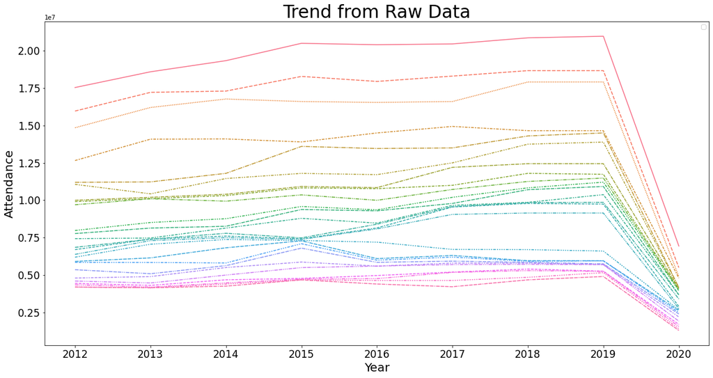

```python
plt.figure(figsize=(20,10))
sns.lineplot(data=merged.T)
plt.legend('')
plt.title("Trend from Raw Data",fontsize=30)
plt.xlabel("Year",fontsize=20)
plt.ylabel("Attendance",fontsize=20)
plt.xticks(fontsize=17)
plt.yticks(fontsize=17)
plt.show()
```

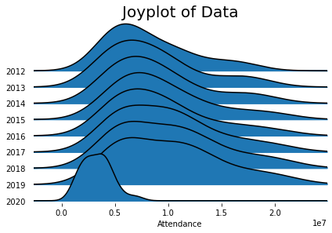

```python
#joyplot
plt.figure(figsize=(20,10))
fig, axes = joypy.joyplot(merged,ylim="own")
plt.title("Joyplot of Data",fontsize=20)
plt.xlabel("Attendance")
plt.show()
```

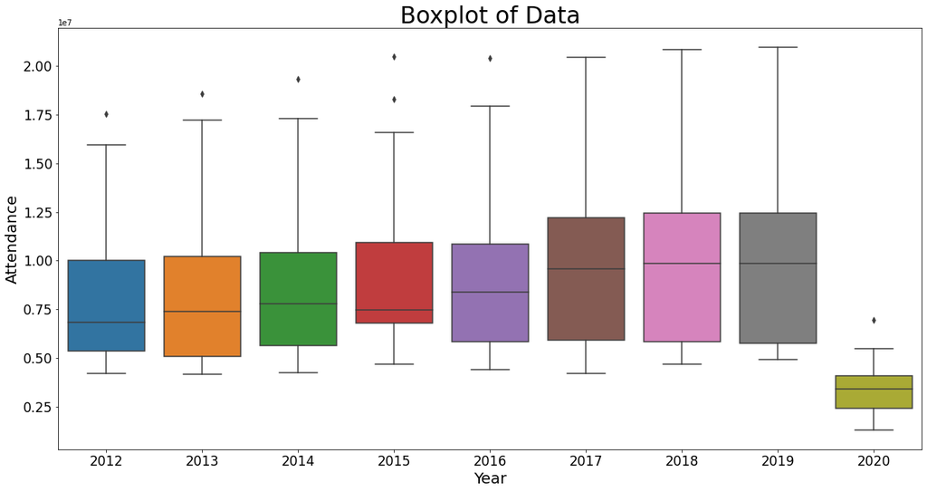

```python
plt.figure(figsize=(20,10))
sns.boxplot(data=merged)
plt.title("Boxplot of Data",fontsize=30)
plt.xlabel("Year",fontsize=20)
plt.ylabel("Attendance",fontsize=20)
plt.xticks(fontsize=17)
plt.yticks(fontsize=17)
plt.show()
```

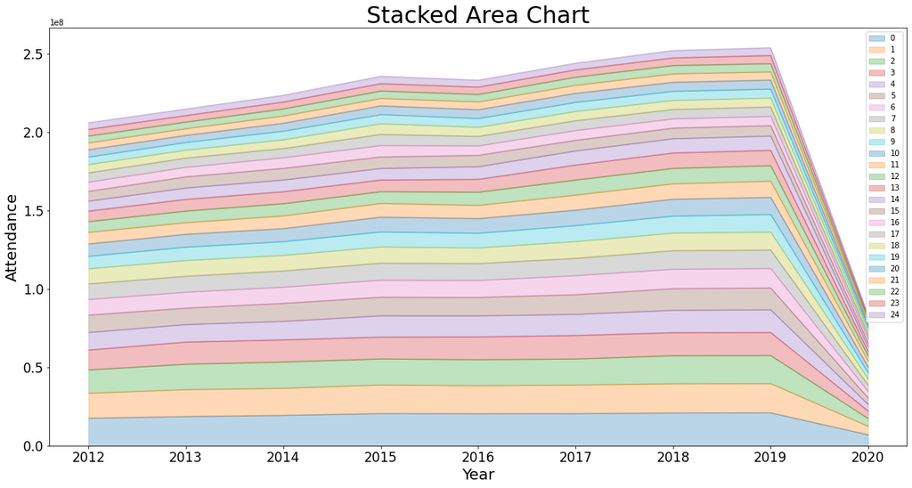

```python
merged.T.plot(kind='area',
    stacked=True,
    figsize=(20, 10), # pass a tuple (x, y) size
    alpha=0.3
)
plt.title("Stacked Area Chart",fontsize=30)
plt.xlabel("Year",fontsize=20)
plt.ylabel("Attendance",fontsize=20)
plt.xticks(fontsize=17)
plt.yticks(fontsize=17)
plt.legend()
plt.show()
```

The above shows multiple visualisations for the data per year. It is clear that there is a significant dip in the attendance in 2020 (evident from every visualisation), as compared to the general steady increase in attendance. From the raw data we can see that each rank has an increasing trend in general, and the spread is seen to increase from the joyplot. The total is seen to increase from the stacked area chart. From the boxplot we see that the minimum (25th ranking) is staying relatively constant, while the maximum (1st ranking) is increasing over the years. Also, the median is seeing a gradual increase, too.

The following below will be similar to above, but analysing the `merged_change` DataFrame instead.

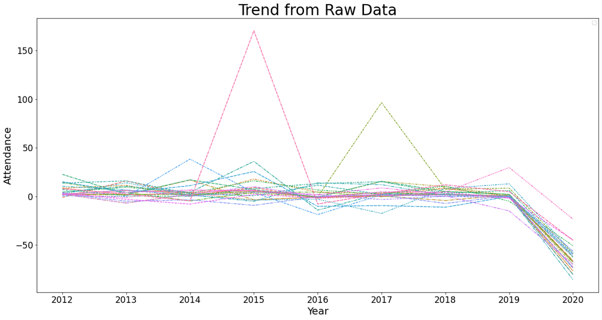

```python
plt.figure(figsize=(20,10))
sns.lineplot(data=merged_change.T)
plt.legend('')
plt.title("Trend from Raw Data",fontsize=30)
plt.xlabel("Year",fontsize=20)
plt.ylabel("Attendance",fontsize=20)
plt.xticks(fontsize=17)
plt.yticks(fontsize=17)
plt.show()
```

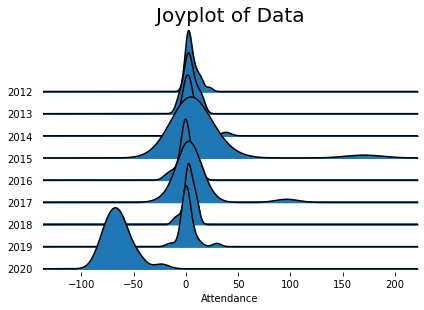

```python
#joyplot
plt.figure(figsize=(20,10))
fig, axes = joypy.joyplot(merged_change,ylim="own")
plt.title("Joyplot of Data",fontsize=20)
plt.xlabel("Attendance")
plt.show()
```

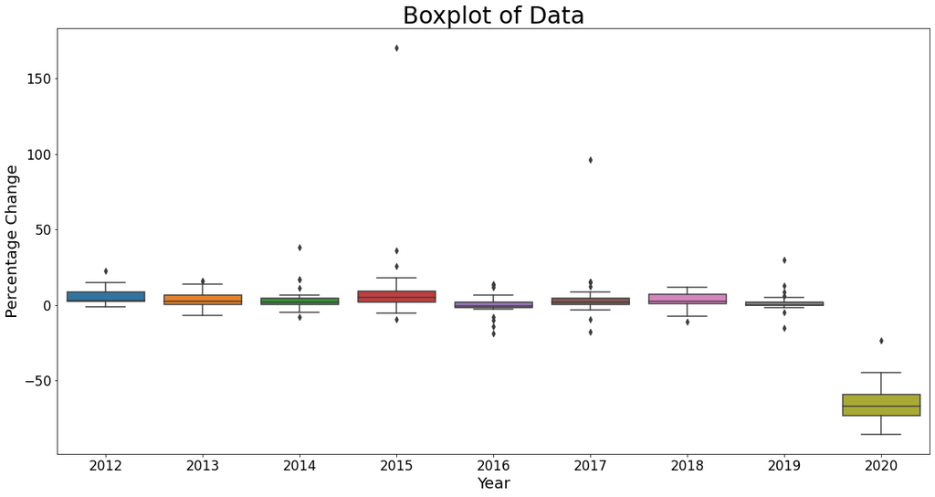

```python
plt.figure(figsize=(20,10))
sns.boxplot(data=merged_change)
plt.title("Boxplot of Data",fontsize=30)
plt.xlabel("Year",fontsize=20)
plt.ylabel("Percentage Change",fontsize=20)
plt.xticks(fontsize=17)
plt.yticks(fontsize=17)
plt.show()
```

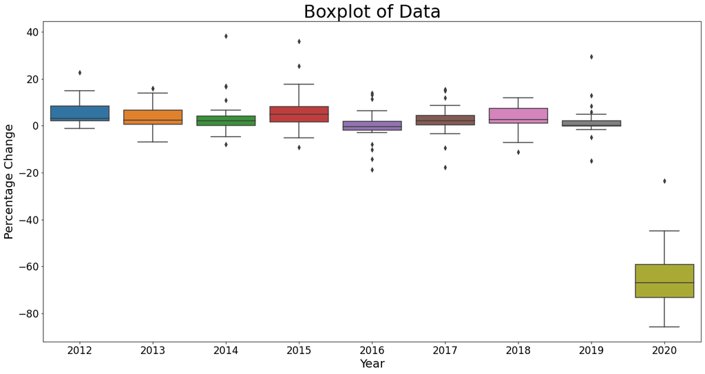

```python
plt.figure(figsize=(20,10))
sns.boxplot(data=merged_change[merged_change<50])
plt.title("Boxplot of Data",fontsize=30)
plt.xlabel("Year",fontsize=20)
plt.ylabel("Percentage Change",fontsize=20)
plt.xticks(fontsize=17)
plt.yticks(fontsize=17)
plt.show()
```

```python
merged_change.iloc[:,-1].describe()["50%"]
```

```
-66.9
```

It is evident from the joyplot that the change in 2020 was very different from usual, with the general change in attendance hovering around 0%, but in 2020 this has an average of below -50%. Similarly, from the boxplot, it can be seen that the smallest decrease in 2020 was almost the same as the worst decrease across all years from 2012 to 2019. In addition, the median decrease in 2020 was -66.9%, which is a drop to aproximately 1/3 of the previous year.

### Dataset 2

The following visualisations will be about the crowd levels using `df_list16` and `df_list19`, for a general sense of how the data looks, and afterwards closer analysis using `open16`, `open19`, and `month2020`.

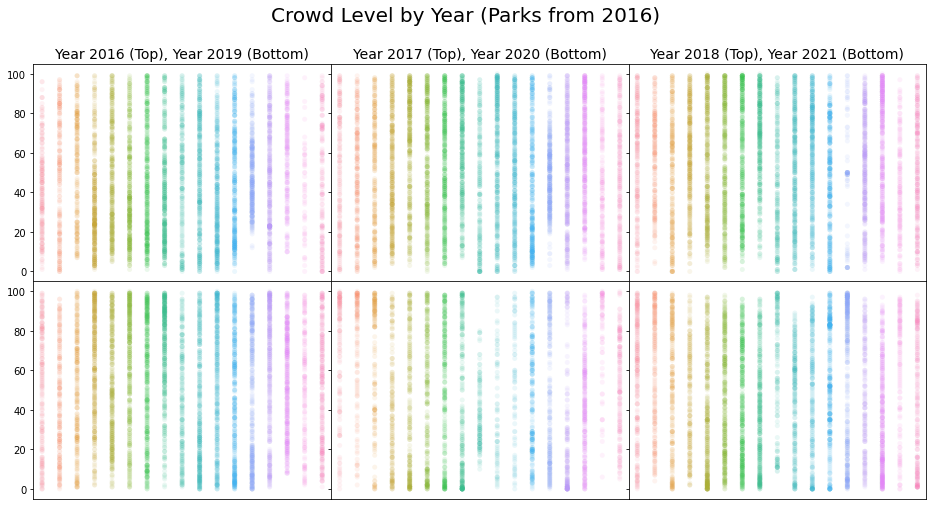

```python
#define number of rows and columns for subplots
nrow=2
ncol=3

# make a list of all dataframes
fig = plt.figure(figsize=(16,8))
gs = fig.add_gridspec(nrow, ncol, hspace=0, wspace=0)
axes = gs.subplots(sharex=True, sharey=True)

# plot counter
count=0
for r in range(nrow):
    for c in range(ncol):
        sns.stripplot(data=df_list16[count],alpha=0.1,jitter=False,ax=axes[r,c])
        if (r==0):
            axes[r,c].set_title ('Year ' + str(count+2016) + ' (Top), Year ' + str(count+2019) + ' (Bottom)',fontsize=14)
        count+=1

for ax in axes.flat:
    ax.label_outer()
    ax.tick_params(axis='x', bottom=False, labelbottom=False)

plt.suptitle("Crowd Level by Year (Parks from 2016)", fontsize=20)
```

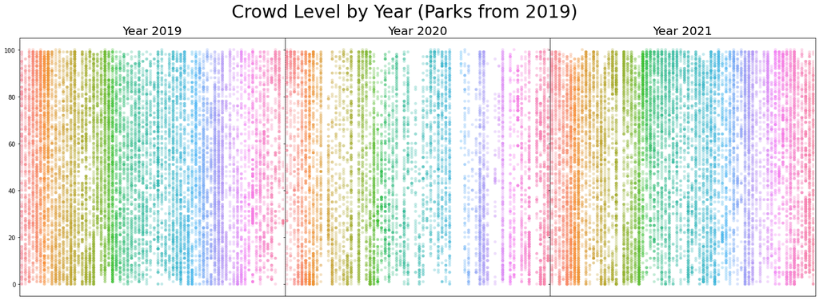

```python
#define number of rows and columns for subplots
nrow=1
ncol=3

# make a list of all dataframes
fig = plt.figure(figsize=(24,8))
gs = fig.add_gridspec(nrow, ncol, hspace=0, wspace=0)
axes = gs.subplots(sharex=True, sharey=True)

# plot counter
count=0
for r in range(nrow):
    for c in range(ncol):
        sns.stripplot(data=df_list19[count],alpha=0.3,jitter=False,ax=axes[c])
        axes[c].set_title ('Year ' + str(count+2019),fontsize=20)
        count+=1

for ax in axes.flat:
    ax.label_outer()
    ax.tick_params(axis='x', bottom=False, labelbottom=False)

plt.suptitle("Crowd Level by Year (Parks from 2019)", fontsize=30)
```

The difference is not so apparent by looking at the parks from 2016, but looking at the parks from 2019, we can see that the year 2020 has significantly more white space (no data) as compared to 2019. 2021 is in between both of them, showing that the amusement parks are recovering from the pandemic. These however are not great ways to visualise the data; the percentage of crowd seems to be a number relative to the rest of the year instead of comparing absolute numbers. The heatmaps below provide a better visualisation, by instead considering the number of days a park is open in certain periods of time.

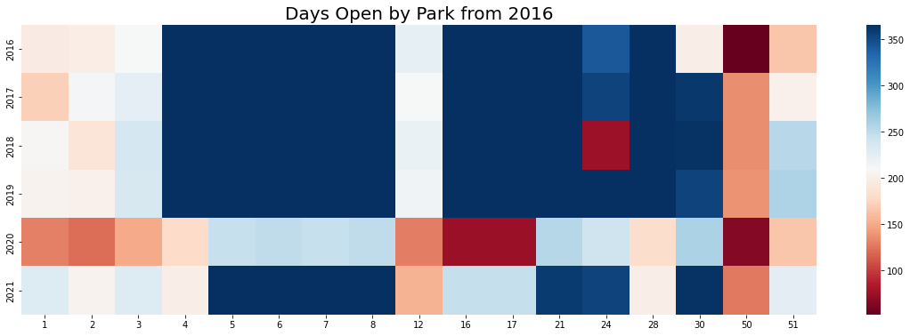

```python
plt.figure(figsize=(20,6))
ax = sns.heatmap(open16, cmap="RdBu")
plt.title("Days Open by Park from 2016",fontsize=20)
```

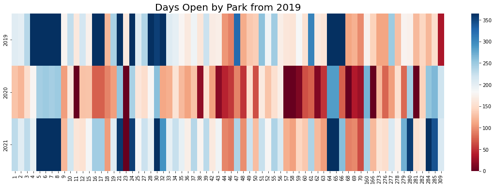

```python
plt.figure(figsize=(20,6))
ax = sns.heatmap(open19, cmap="RdBu")
plt.title("Days Open by Park from 2019",fontsize=20)
```

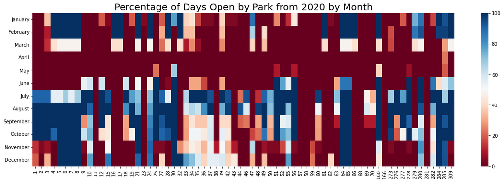

```python
plt.figure(figsize=(20,6))
ax = sns.heatmap(month2020, cmap="RdBu")
plt.title("Percentage of Days Open by Park from 2020 by Month",fontsize=20)
```

From these, we can see the effects of the pandemic on amusement parks. For the parks that were open since 2016, in general it is clear that 2020's days open is lower than the other days. Similarly, for the days open since 2019, there are obvious red blocks in 2020, indicating a drop in the number of days open. In addition, the colour pattern in 2021 is quite similar to 2019, which indicates that most parks have recovered from the closure in 2020 from the pandemic.

As for the number of days open by park in 2020, adjusted by percentage because different months have different numbers of days, it can be seen that almost every park is fully closed in April. From June, some parks start opening, but the increase in the number of days open does not last long for certain parks. There are some parks which remain closed for the rest of 2020. There are also many parks which closed in November and December.

# Results Findings & Conclusion

For each research question, summarize in 2-3 visualizations which will answer the question. Intrepret the results accordingly and give your observation and conclusion. The visualizations should be well presented (apply what you have learnt in Chapter 9 on data communication). The plots shown here could be an enhanced version of the EDA plots, or presented in another format.

## Question 1 (Trend and Drop)

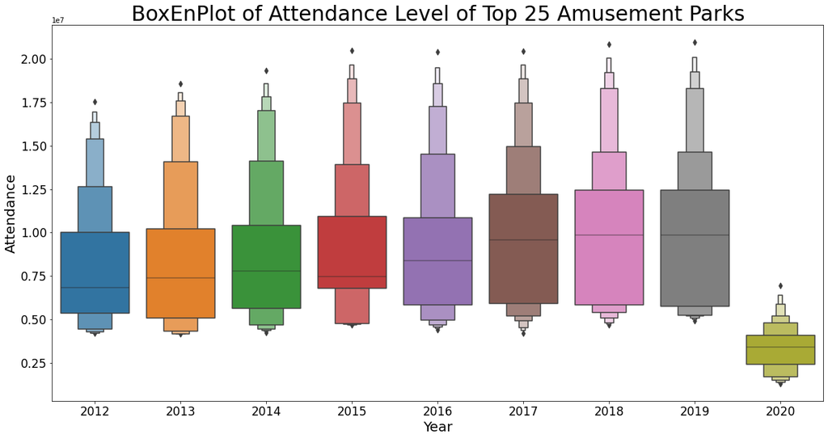

```python
plt.figure(figsize=(20,10))
sns.boxenplot(data=merged,k_depth="full")
plt.title("BoxEnPlot of Attendance Level of Top 25 Amusement Parks",fontsize=30)
plt.xlabel("Year",fontsize=20)
plt.ylabel("Attendance",fontsize=20)
plt.xticks(fontsize=17)
plt.yticks(fontsize=17)
plt.show()
```

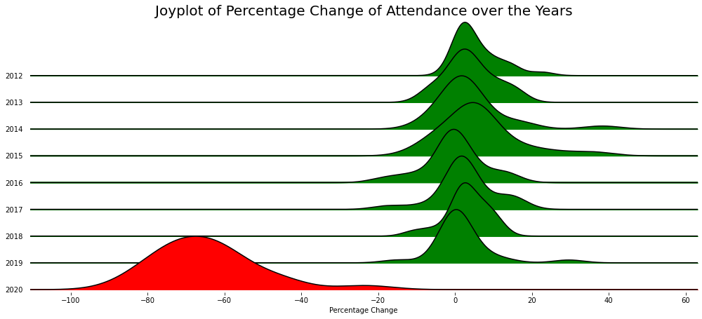

```python
#joyplot
fig, axes = joypy.joyplot(merged_change[merged_change<50],ylim="own",color=["green","green","green","green","green","green","green","green","red"], figsize=(14,6))
plt.title("Joyplot of Percentage Change of Attendance over the Years",fontsize=20)
plt.xlabel("Percentage Change")
plt.show()
```

### 1. Based on the attendance data, was there an increasing trend in the attendance prior to the pandemic? And when the pandemic struck, how drastic was the decrease in attendance?

> From the boxenplot, there is a clear **increasing trend** in the attendance from 2012 through 2019. While the top 25th amusement park by attendance has roughly constant attendance, the median and maximum are increasing in general. The spread is also increasing.

> In 2020, the attendance dropped significantly. The percentage change is more apparent in the joyplot: for years 2012 through 2019, the percentage change hovered slightly over 0%, except for two outliers above 50% which have been removed from the visualisation for the purpose of clarity. However, in 2020, the percentage change has a median of -66.9%, which is a **drop to less than a third of the previous year** (2019).

## Question 2 (Timing of Closure)

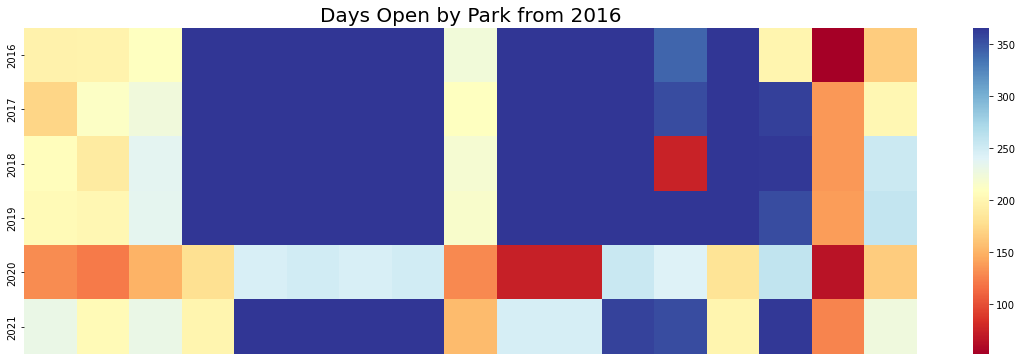

```python
plt.figure(figsize=(20,6))
ax = sns.heatmap(open16, cmap="RdYlBu")
ax.tick_params(labelbottom=False, bottom=False)
plt.title("Days Open by Park from 2016",fontsize=20)
plt.show()
```

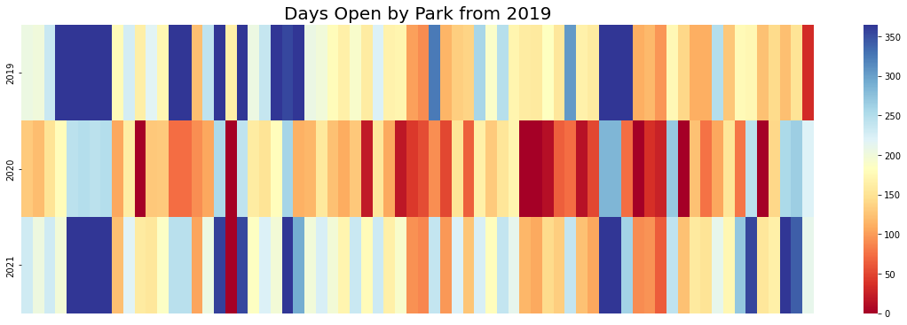

```python
plt.figure(figsize=(20,6))
ax = sns.heatmap(open19, cmap="RdYlBu")
ax.tick_params(labelbottom=False, bottom=False)
plt.title("Days Open by Park from 2019",fontsize=20)
plt.show()
```

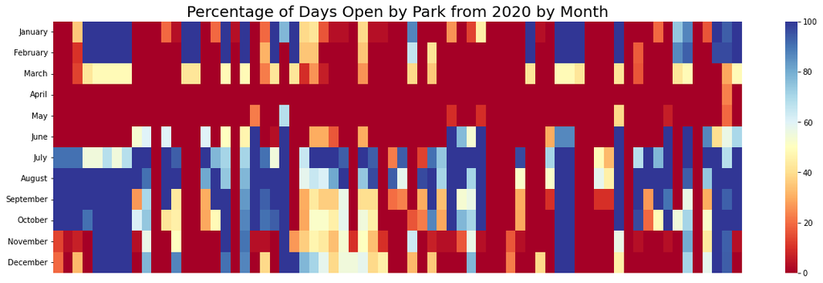

```python
plt.figure(figsize=(20,6))
ax = sns.heatmap(month2020, cmap="RdYlBu")
ax.tick_params(labelbottom=False, bottom=False)
plt.title("Percentage of Days Open by Park from 2020 by Month",fontsize=20)
plt.show()
```

### 2. When did the effects of the pandemic strike? How quickly did amusement parks recover from the pandemic? Did the number of days a park was open for revert to the original number, or was it still affected by the pandemic?

> From the 2016 and 2019 graphs, it is clear that in general, **2020 had the worst effects from the pandemic**. While there have been some slight deviations within the other years, the decrease in number of days open in 2020 is apparent from the different shades in 2020 for each column.

> Seeing from the graph of percentage of days open, **the effect of the pandemic was worst from April to May of 2020**, where almost all parks were fully closed. In June, around half of the parks were still closed. Then **from July onward, most parks which opened in 2020 have already reopened**, and by August they were almost open similar at rates similar to before. There was also closure in November, which I have insufficient information to deduce whether the closure is because of the pandemic or not.

> In addition, looking at the 2019 graph, the colour scheme of the year 2021 is very similar to that of 2019, apart from a few parks which might just be having other improvements over the years. But this highlights the fact that **parks have restored their opening days back to the original number** for the most part.

# Recommendations or Further Works

State any recommendations, improvements or further works.

When the AECOM 2021 Theme Index is released, there will be better comparisons to see how well the amusement parks are recovering from the pandemic. An improvement to this is to find a way to make use of the percentage crowd level, as opposed to using it mainly as an indicator of closure. As for other improvements, it would be great if there was better access to other datasets, for example the data from Statista locked behind a paywall.

It would also be great if I found a better visualisation for the second dataset. The heatmaps work, but if there was a better way to demonstrate the changes, it would be a great improvement.

# References

Cite any references made, and links where you obtained the data. You may wish to read about how to use markdown in Jupyter notebook to make your report easier to read. https://www.ibm.com/docs/en/db2-event-store/2.0.0?topic=notebooks-markdown-jupyter-cheatsheet

https://aecom.com for the Theme Indexes,  
https://queue-times.com for the data on attendance.

https://tabula-py.readthedocs.io/en/latest/tabula.html for the tabula.py pdf reader, (installation via `%pip install tabula` followed by `import tabula`)  
https://beautiful-soup-4.readthedocs.io/en/latest/ for the BeautifulSoup parser for raw HTML data. (installation via `%pip install bs4` followed by `from bs4 import BeautifulSoup`)